# Getting Started with SWAT

SWAT (SAS Wrapper for Analytics Transfer) is the Python module used to interface with SAS' Cloud Analytics Services (CAS). This module includes classes and functions to call actions on the server, and process the results on the client. This workshop will cover the basics of connecting to CAS from Python, calling CAS actions, interacting with CAS tables, and using the results of the CAS actions on the client.

We will cover several aspects of working with CAS in the following sections. These include:

- Connecting to CAS
- Running CAS actions
- Getting help on CAS actions
- Loading data into CAS
- Using `CASTable` as a DataFrame
- Doing simple statistics
- Grouping data
- SQL
- DATA step
- Building Analytical Models

## Exercise 1 - Connecting to CAS

The SWAT module in Python is merely a CAS client, it does not start the server. So the first thing you need to do is get access to a running CAS server. To connect to the server, we need the hostname and port number that the server is running at as well as a way to authenticate with the server.

There are various ways of authenticating with CAS, so you will need to check with your system administrator as to the proper method to use. The simplest form of authentication is username and password, and we will cover that here.

To connect to CAS, we will use the `CAS` class in the SWAT package. The most basic form of creating a connection is to supply the CAS host, port, username, and password to the `CAS` class.

```python
import swat

conn = swat.CAS('sasserver.demo.sas.com', 5570)
```

We can print the CAS object to see the settings for that session. It includes the host, port, username, protocol, session name, and session ID. The host, port, and username should be self-explanatory. The protocol can be 'cas' for the binary protocol, 'http' for the unencrypted REST interface, or 'https' for the encrypted REST interface.

The session name is simply a human-readable tag given to a session so it is easier to identify in actions that display session information. The session ID is a unique identifier given to each session. The session ID can be used to reconnect to a session, or connect from another client.

```python
conn
```

```
CAS('sasserver.demo.sas.com', 5570, 'viyauser', protocol='cas', name='py-session-2', session='95117b0a-44e6-5c4c-8cf3-aa242c1d8316')
```

### Authinfo Authentication

It's generally not a good idea to put your username and password into a program, so the CAS class also supports Authinfo authentication. This is a method of storing your username and password in a file that is readable only by you. The CAS object can then safely read the username and password from that file. This file was used in the connection above which is why you didn't need to enter a username or password.

The basic format of the file is to put a host, port, username, and password on each line.

```
host my-cas.com port 12345 user my-name password s3cr3t
```

The hostname must exactly match the hostname used in the `CAS` object. If no port number is specified on the line, the username and password will be used for any port on that machine.

By default, the file should be stored in `~/.authinfo`, and it should be readable only by you. On Linux, the command to do this is:

```
chmod 0600 ~/.authinfo
```

Once you have a file with the appropriate authentication information, you can create a `CAS` object without specifying a username and password.

## Exercise 2 - Running CAS Actions

Now that we have a CAS connection, we can try running some CAS actions. Let's start with the `serverstatus` action. This action displays some basic status information about tha CAS server such as platform and release information, the number of nodes, and information about each node in the grid.

CAS actions are called on `CAS` objects just like Python methods. We will store the result of the action call in `out` as well as display the result.

```python
out = conn.serverstatus()
out
```

```
NOTE: Grid node action status report: 1 nodes, 26 total actions executed.
```

**§ About**

{'Copyright': 'Copyright © 2014-2016 SAS Institute Inc. All Rights Reserved.', 'Version': '3.01', 'CAS': 'Cloud Analytic Services', 'license': {'gracePeriod': 45, 'maxCPUs': 9999, 'expires': '29Nov2016:00:00:00', 'siteNum': 70068118, 'site': '28Aug2015 English Only AIX Conf', 'warningPeriod': 55}, 'System': {'Model Number': 'x86_64', 'OS Family': 'LIN X64', 'Hostname': 'sasserver', 'OS Name': 'Linux', 'OS Version': '#1 SMP Tue Jul 12 18:30:56 UTC 2016', 'OS Release': '2.6.32-642.3.1.el6.x86_64'}, 'VersionLong': 'V.03.01M0P08282016'}

**§ server**

Server Status

|  | nodes | actions |
| --- | --- | --- |
| 0 | 1 | 26 |

**§ nodestatus**

Node Status

|  | name | role | uptime | running | stalled |
| --- | --- | --- | --- | --- | --- |
| 0 | sasserver.demo.sas.com | controller | 0.16 | 0 | 0 |

elapsed 0.00269s · user 0.001s · sys 0.001s · mem 0.0761MB

The result of every CAS action is a `CASResults` object. `CASResults` objects are simply a subclass of Python's ordered dictionary, so anything that you can do with Python dictionaries can also be done with `CASResults` objects. For example, we can print all of the result keys using the `keys` method.

```python
list(out.keys())
```

```
['About', 'server', 'nodestatus']
```

You can also access the objects at each key using dictionary syntax.

```python
out['nodestatus']
```

Node Status

|  | name | role | uptime | running | stalled |
| --- | --- | --- | --- | --- | --- |
| 0 | sasserver.demo.sas.com | controller | 0.16 | 0 | 0 |

The types of the objects at each key vary from action to action. In the case of `serverstatus`, the 'About' key holds a dictionary, and the 'server' and 'nodestatus' keys hold DataFrames.

```python
[type(x) for x in out.values()]
```

```
[dict, swat.dataframe.SASDataFrame, swat.dataframe.SASDataFrame]
```

As you can see, the DataFrames held in the output are `SASDataFrame` objects. The `SASDataFrame` object is a subclass of Pandas `DataFrame`. This means that they can be treated as equivalents. The `SASDataFrame` object simply adds some extra SAS metadata such as titles, labels, formats, etc.

Of course, since it is a DataFrame, we can use indexing, sorting, and filtering operations on it.

```python
nodestatus = out['nodestatus']
nodestatus[nodestatus['role'] == 'worker']
```

Node Status

|  | name | role | uptime | running | stalled |
| --- | --- | --- | --- | --- | --- |

```python
nodestatus[nodestatus['role'] == 'controller']
```

Node Status

|  | name | role | uptime | running | stalled |
| --- | --- | --- | --- | --- | --- |
| 0 | sasserver.demo.sas.com | controller | 0.16 | 0 | 0 |

```python
nodestatus = nodestatus.set_index('name')
nodestatus.loc['sasserver.demo.sas.com']
```

```
role       controller
uptime           0.16
running             0
stalled             0
Name: sasserver.demo.sas.com, dtype: object
```

Now that we've covered the basics of calling CAS actions and traversing the results, let's see what other actions are available.

## Exercise 3 - Getting Help on CAS Actions

### 3.1 Using CAS' `help` Function

So far we've only introduced the `serverstatus` action. However, there are many actions that are available in all CAS installations, and various other may be available depending which products have been licensed. To display all available actions, you use the `help` action. (Note that we added the semi-colon at the end to suppress the rendering of the output which is a DataFrame of the same information that is displayed in the notes.)

```python
conn.help();
```

```
NOTE: Available Action Sets and Actions:
NOTE:    accessControl
NOTE:       assumeRole - Assumes a role
NOTE:       dropRole - Relinquishes a role
NOTE:       showRolesIn - Shows the currently active role
NOTE:       showRolesAllowed - Shows the roles that a user is a member of
NOTE:       isInRole - Shows whether a role is assumed
NOTE:       isAuthorized - Shows whether access is authorized
NOTE:       isAuthorizedActions - Shows whether access is authorized to actions
NOTE:       isAuthorizedTables - Shows whether access is authorized to tables
NOTE:       isAuthorizedColumns - Shows whether access is authorized to columns
NOTE:       listAllPrincipals - Lists all principals that have explicit access controls
NOTE:       whatIsEffective - Lists effective access and explanations (Origins)
NOTE:       listAcsData - Lists access controls for caslibs, tables, and columns
NOTE:       listAcsActionSet - Lists access controls for an action or action set
NOTE:       repAllAcsCaslib - Replaces all access controls for a caslib
NOTE:       repAllAcsTable - Replaces all access controls for a table
NOTE:       repAllAcsColumn - Replaces all access controls for a column
NOTE:       repAllAcsActionSet - Replaces all access controls for an action set
NOTE:       repAllAcsAction - Replaces all access controls for an action
NOTE:       updSomeAcsCaslib - Adds, deletes, and modifies some access controls for a caslib
NOTE:       updSomeAcsTable - Adds, deletes, and modifies some access controls for a table
NOTE:       updSomeAcsColumn - Adds, deletes, and modifies some access controls for a column
NOTE:       updSomeAcsActionSet - Adds, deletes, and modifies some access controls for an action set
NOTE:       updSomeAcsAction - Adds, deletes, and modifies some access controls for an action
NOTE:       remAllAcsData - Removes all access controls for a caslib, table, or column
NOTE:       remAllAcsActionSet - Removes all access controls for an action set or action
NOTE:       operTableMd - Adds, deletes, and modifies table metadata
NOTE:       operColumnMd - Adds, deletes, and modifies column metadata
NOTE:       operActionSetMd - Adds, deletes, and modifies action set metadata
NOTE:       operActionMd - Adds, deletes, and modifies action metadata
NOTE:       operAdminMd - Assigns users and groups to roles and modifies administrator metadata
NOTE:       listMetadata - Lists the metadata for caslibs, tables, columns, action sets, actions, or administrators
NOTE:       persistMetadata - Persists the access control metadata
NOTE:       createBackup - Creates a backup if one is not in progress
NOTE:       completeBackup - Flags a backup as complete
NOTE:       operBWPaths - Configures a blacklist or whitelist of paths
NOTE:       deleteBWList - Deletes a blacklist or a whitelist
NOTE:    builtins
NOTE:       addNode - Adds a machine to the server
```

[output cut: 100 more lines]

```
NOTE:       addTable - Add a table by sending it from the client to the server
NOTE:       tableInfo - Shows information about a table
NOTE:       tableDetails - Get detailed information about a table
NOTE:       dropTable - Drops a table
NOTE:       deleteSource - Delete a table or file from a caslib's data source
NOTE:       fileInfo - Lists the files in a caslib's data source
NOTE:       promote - Promote a table to global scope
NOTE:       addCaslib - Adds a new caslib to enable access to a data source
NOTE:       dropCaslib - Drops a caslib
NOTE:       caslibInfo - Shows caslib information
NOTE:       queryCaslib - Checks whether a caslib exists
NOTE:       partition - Partitions a table
NOTE:       recordCount - Shows the number of rows in a Cloud Analytic Services table
NOTE:       loadDataSource - Loads one or more data source interfaces
NOTE:       update - Updates rows in a table
```

You can also ask for help on specifc action sets and actions.

```python
conn.help(actionset='builtins');
```

```
NOTE: Information for action set 'builtins':
NOTE:    builtins
NOTE:       addNode - Adds a machine to the server
NOTE:       removeNode - Remove one or more machines from the server
NOTE:       help - Shows the parameters for an action or lists all available actions
NOTE:       listNodes - Shows the host names used by the server
NOTE:       loadActionSet - Loads an action set for use in this session
NOTE:       installActionSet - Loads an action set in new sessions automatically
NOTE:       log - Shows and modifies logging levels
NOTE:       queryActionSet - Shows whether an action set is loaded
NOTE:       queryName - Checks whether a name is an action or action set name
NOTE:       reflect - Shows detailed parameter information for an action or all actions in an action set
NOTE:       serverStatus - Shows the status of the server
NOTE:       about - Shows the status of the server
NOTE:       shutdown - Shuts down the server
NOTE:       getUsers - Shows the users from the authentication provider
NOTE:       getGroups - Shows the groups from the authentication provider
NOTE:       userInfo - Shows the user information for your connection
NOTE:       actionSetInfo - Shows the build information from loaded action sets
NOTE:       history - Shows the actions that were run in this session
NOTE:       casCommon - Provides parameters that are common to many actions
NOTE:       ping - Sends a single request to the server to confirm that the connection is working
NOTE:       echo - Prints the supplied parameters to the client log
NOTE:       modifyQueue - Modifies the action response queue settings
NOTE:       getLicenseInfo - Shows the license information for a SAS product
NOTE:       refreshLicense - Refresh SAS license information from a file
NOTE:       httpAddress - Shows the HTTP address for the server monitor
```

```python
conn.help(action='tableinfo');
```

```
NOTE: Information for action 'table.tableInfo':
NOTE: The following parameters are accepted.  Default values are shown.
NOTE:    string name=NULL (alias: table),
NOTE:       specifies the table name.
NOTE:    string caslib=NULL,
NOTE:       specifies the caslib containing the table that you want to use with the action. By default, the active caslib is used. Specify a value only if you need to access a table from a different caslib.
NOTE:    boolean quiet=false (alias: silent)
NOTE:       when set to True, attempting to show information for a table that does not exist returns an OK status and severity. When set to False, attempting to show information for a table that does not exist returns an error.
```

### 3.2 Using Python's `help` Function

In addition to the `help` action in CAS, you can also use Python's `help` function to retrieve the help content in a Pythonic way. This will display both the help for the CAS action as well as information about the Python object driving the action.

```python
help(conn.tableinfo)
```

```
Help on table.Tableinfo in module swat.cas.actions object:

class table.Tableinfo(CASAction)
 |  Shows information about a table
 |  Parameters
 |  ----------
 |  name : string or CASTable, optional
 |      specifies the table name.
 |  caslib : string, optional
 |      specifies the caslib containing the table that you want to use with
 |      the action. By default, the active caslib is used. Specify a value
 |      only if you need to access a table from a different caslib.
 |  quiet : boolean, optional
 |      when set to True, attempting to show information for a table that
 |      does not exist returns an OK status and severity. When set to False,
 |      attempting to show information for a table that does not exist
 |      returns an error.
 |      Default: False
 |  Returns
 |  -------
 |  Tableinfo object
 |  Method resolution order:
 |      table.Tableinfo
 |      CASAction
 |      swat.cas.utils.params.ParamManager
 |      builtins.object
 |  Methods defined here:
 |  __call__(_self_, name=None, caslib=None, quiet=None, **kwargs)
 |      Shows information about a table
 |      Parameters
 |      ----------
 |      name : string or CASTable, optional
 |          specifies the table name.
 |      caslib : string, optional
 |          specifies the caslib containing the table that you want to use with
 |          the action. By default, the active caslib is used. Specify a value
 |          only if you need to access a table from a different caslib.
 |      quiet : boolean, optional
 |          when set to True, attempting to show information for a table that
 |          does not exist returns an OK status and severity. When set to False,
```

[output cut: 283 more lines]

```
 |      *args : any, optional
 |          Additional arguments to json.dumps
 |      **kwargs : any, optional
 |          Additional arguments to json.dumps
 |      Returns
 |      -------
 |      string
 |  to_params = to_dict(self)
 |      Return the parameters as a dictionary
 |  ----------------------------------------------------------------------
 |  Data descriptors inherited from swat.cas.utils.params.ParamManager:
 |  __dict__
 |      dictionary for instance variables (if defined)
 |  __weakref__
 |      list of weak references to the object (if defined)
```

### 3.3 Using IPython's or Jupyter's Help Functionality

If you are using IPython or a Jupyter notebook, it has another variant of the help information stored in Python objects. To invoke IPython/Jupyter's help, you simply append a **?** to the class/method/function you want help for.

```python
conn.tableinfo?
```

### 3.4 Tab Completion

While it doesn't display true help information, tab completion of action names is also available in IPython and Jupyter. All currently loaded action sets and actions will show up in the tab completion for a CAS connection object.

```python
#conn.
```

## Exercise 4 - Loading Data into CAS

So far we've run a few CAS actions and taken a look at the output that they create, but we haven't done anything that requires data. In order to do that, we need to know how to load data into a CAS table.

There are many ways of getting data into CAS. We'll look at a couple of them here.

### 4.1 Loading Client-Side Data into CAS

The most Pythonic way of getting data into CAS is to use the Pandas-style data readers on the CAS connection object. When we refer to "client side" data, we mean data that is located on the machine that Python is running on. "Server side" data is data that is on the machine that CAS is running on. These may or may not be the same machine.

One thing to keep in mind when loading client-side data is that all data must be uploaded to the CAS machine. This may be fine for small to medium sized data sets, but for larger data sets you would probably want to move on to the section 4.3 on loading server-side data.

One of the simplest data file formats is CSV. Pandas' `read_csv` function is a very capable CSV reader with many options. You can use the SWAT version of that same function on the CAS connection object. It supports all of the same options as the Pandas version (and actually uses it in the background). The difference is that the SWAT version returns a `CASTable` object rather than a DataFrame.

```python
tbl = conn.read_csv('https://raw.githubusercontent.com/'
                    'sassoftware/sas-viya-programming/master/data/cars.csv')
tbl
```

```
CASTable('_T_8B910465_7F1F62C95F88', caslib='CASUSER(viyauser)')
```

Since the code above uses a Python data parser, the content of the URL must be downloaded to the client machine first, then it gets parsed. The data is then uploaded to CAS. You may want to keep this in mind since it does mean that the data is transferred twice. If you have larger data files, you may want to use an alternative way of loading them.

A `CASTable` object is a Python object interface to a CAS table. You can call CAS actions on it just like a `CAS` connection object. It also supports much of the Pandas DataFrame API. This means that you can treat it like a DataFrame, but all of the operations will be performed on the CAS server using CAS actions.

The first thing we'll do is take a look at the column information using the `columninfo` CAS action.

```python
conn.columninfo(table=tbl)
```

**§ ColumnInfo**

|  | Column | ID | Type | RawLength | FormattedLength | NFL | NFD |
| --- | --- | --- | --- | --- | --- | --- | --- |
| 0 | Make | 1 | varchar | 13 | 13 | 0 | 0 |
| 1 | Model | 2 | varchar | 39 | 39 | 0 | 0 |
| 2 | Type | 3 | varchar | 6 | 6 | 0 | 0 |
| 3 | Origin | 4 | varchar | 6 | 6 | 0 | 0 |
| 4 | DriveTrain | 5 | varchar | 5 | 5 | 0 | 0 |
| 5 | MSRP | 6 | double | 8 | 12 | 0 | 0 |
| 6 | Invoice | 7 | double | 8 | 12 | 0 | 0 |
| 7 | EngineSize | 8 | double | 8 | 12 | 0 | 0 |
| 8 | Cylinders | 9 | double | 8 | 12 | 0 | 0 |
| 9 | Horsepower | 10 | double | 8 | 12 | 0 | 0 |
| 10 | MPG_City | 11 | double | 8 | 12 | 0 | 0 |
| 11 | MPG_Highway | 12 | double | 8 | 12 | 0 | 0 |
| 12 | Weight | 13 | double | 8 | 12 | 0 | 0 |
| 13 | Wheelbase | 14 | double | 8 | 12 | 0 | 0 |
| 14 | Length | 15 | double | 8 | 12 | 0 | 0 |

elapsed 0.00065s · mem 0.132MB

We can also fetch a sample of the data using the `fetch` CAS action.

```python
conn.fetch(table=tbl, to=5)
```

**§ Fetch**

Selected Rows from Table _T_8B910465_7F1F62C95F88

|  | Make | Model | Type | Origin | DriveTrain | MSRP | Invoice | EngineSize | Cylinders | Horsepower | MPG_City | MPG_Highway | Weight | Wheelbase | Length |
| --- | --- | --- | --- | --- | --- | --- | --- | --- | --- | --- | --- | --- | --- | --- | --- |
| 0 | Acura | MDX | SUV | Asia | All | 36945.0 | 33337.0 | 3.5 | 6.0 | 265.0 | 17.0 | 23.0 | 4451.0 | 106.0 | 189.0 |
| 1 | Acura | RSX Type S 2dr | Sedan | Asia | Front | 23820.0 | 21761.0 | 2.0 | 4.0 | 200.0 | 24.0 | 31.0 | 2778.0 | 101.0 | 172.0 |
| 2 | Acura | TSX 4dr | Sedan | Asia | Front | 26990.0 | 24647.0 | 2.4 | 4.0 | 200.0 | 22.0 | 29.0 | 3230.0 | 105.0 | 183.0 |
| 3 | Acura | TL 4dr | Sedan | Asia | Front | 33195.0 | 30299.0 | 3.2 | 6.0 | 270.0 | 20.0 | 28.0 | 3575.0 | 108.0 | 186.0 |
| 4 | Acura | 3.5 RL 4dr | Sedan | Asia | Front | 43755.0 | 39014.0 | 3.5 | 6.0 | 225.0 | 18.0 | 24.0 | 3880.0 | 115.0 | 197.0 |

elapsed 0.0065s · user 0.002s · mem 0.569MB

#### Calling Actions from CASTable Objects

As you can see in the previous two code samples, we ran the CAS action on the connection object and supplied the table in the `table=` parameter. Since this is such a common thing to do, the `CASTable` object can also be used as the action dispatcher. In this case, you simply call the action on the `CASTable` object itself, and don't specify a `table=` parameter. The `table=` parameter will be automatically populated with the table information.

```python
tbl.fetch(to=5)
```

**§ Fetch**

Selected Rows from Table _T_8B910465_7F1F62C95F88

|  | Make | Model | Type | Origin | DriveTrain | MSRP | Invoice | EngineSize | Cylinders | Horsepower | MPG_City | MPG_Highway | Weight | Wheelbase | Length |
| --- | --- | --- | --- | --- | --- | --- | --- | --- | --- | --- | --- | --- | --- | --- | --- |
| 0 | Acura | MDX | SUV | Asia | All | 36945.0 | 33337.0 | 3.5 | 6.0 | 265.0 | 17.0 | 23.0 | 4451.0 | 106.0 | 189.0 |
| 1 | Acura | RSX Type S 2dr | Sedan | Asia | Front | 23820.0 | 21761.0 | 2.0 | 4.0 | 200.0 | 24.0 | 31.0 | 2778.0 | 101.0 | 172.0 |
| 2 | Acura | TSX 4dr | Sedan | Asia | Front | 26990.0 | 24647.0 | 2.4 | 4.0 | 200.0 | 22.0 | 29.0 | 3230.0 | 105.0 | 183.0 |
| 3 | Acura | TL 4dr | Sedan | Asia | Front | 33195.0 | 30299.0 | 3.2 | 6.0 | 270.0 | 20.0 | 28.0 | 3575.0 | 108.0 | 186.0 |
| 4 | Acura | 3.5 RL 4dr | Sedan | Asia | Front | 43755.0 | 39014.0 | 3.5 | 6.0 | 225.0 | 18.0 | 24.0 | 3880.0 | 115.0 | 197.0 |

elapsed 0.00218s · user 0.002s · mem 0.569MB

### 4.2 Parsing Client-Side Data on the Server

Another option for processing client-side data is to upload it as-is and let CAS parse it. This is generally faster since there isn't the additional overhead of converting Python objects to data in a form that CAS can read it. In addition, some file formats such as CSV can be parsed in parallel in CAS which gives another performance boost.

The example below uploads the same file as above, but this time CAS is doing the parsing. You should note that since this CSV file is a URL, the data must be downloaded to the client machine and then uploaded to CAS which adds a bit more overhead.

```python
tbl2 = conn.upload_file('https://raw.githubusercontent.com/'
                        'sassoftware/sas-viya-programming/master/data/cars.csv')
```

```
NOTE: Cloud Analytic Services made the uploaded file available as table CARS in caslib CASUSER(viyauser).
NOTE: The table CARS has been created in caslib CASUSER(viyauser) from binary data uploaded to Cloud Analytic Services.
```

```python
tbl2.fetch(to=5)
```

**§ Fetch**

Selected Rows from Table CARS

|  | Make | Model | Type | Origin | DriveTrain | MSRP | Invoice | EngineSize | Cylinders | Horsepower | MPG_City | MPG_Highway | Weight | Wheelbase | Length |
| --- | --- | --- | --- | --- | --- | --- | --- | --- | --- | --- | --- | --- | --- | --- | --- |
| 0 | Acura | MDX | SUV | Asia | All | 36945.0 | 33337.0 | 3.5 | 6.0 | 265.0 | 17.0 | 23.0 | 4451.0 | 106.0 | 189.0 |
| 1 | Acura | RSX Type S 2dr | Sedan | Asia | Front | 23820.0 | 21761.0 | 2.0 | 4.0 | 200.0 | 24.0 | 31.0 | 2778.0 | 101.0 | 172.0 |
| 2 | Acura | TSX 4dr | Sedan | Asia | Front | 26990.0 | 24647.0 | 2.4 | 4.0 | 200.0 | 22.0 | 29.0 | 3230.0 | 105.0 | 183.0 |
| 3 | Acura | TL 4dr | Sedan | Asia | Front | 33195.0 | 30299.0 | 3.2 | 6.0 | 270.0 | 20.0 | 28.0 | 3575.0 | 108.0 | 186.0 |
| 4 | Acura | 3.5 RL 4dr | Sedan | Asia | Front | 43755.0 | 39014.0 | 3.5 | 6.0 | 225.0 | 18.0 | 24.0 | 3880.0 | 115.0 | 197.0 |

elapsed 0.00138s · user 0.002s · mem 0.567MB

There is also an `upload_frame` method on the `CAS` connection object that will upload a Pandas DataFrame. This method simply exports the DataFrame to CSV and uploads that file to the server.

### 4.3 Loading Server-Side Data into CAS

If you have larger data sets, you will likely want to keep them on the same machine as your CAS server so that they can be loaded directly. The action used to load data from a file directly is `loadtable`.

```python
conn.caslibinfo()
```

**§ CASLibInfo**

|  | Name | Type | Description | Path | Definition | Subdirs | Local | Active | Personal |
| --- | --- | --- | --- | --- | --- | --- | --- | --- | --- |
| 0 | CASUSER(viyauser) | PATH | Personal File System Caslib | /home/viyauser/ |  | 1.0 | 0.0 | 1.0 | 1.0 |
| 1 | Formats | PATH | CAS Formats caslib | /opt/sas/viya/config/data/cas/default/formats/ |  | 1.0 | 0.0 | 0.0 | 0.0 |
| 2 | Public | PATH | CAS Public caslib | /opt/sas/viya/config/data/cas/default/public/ |  | 1.0 | 0.0 | 0.0 | 0.0 |

elapsed 0.00229s · sys 0.002s · mem 0.055MB

```python
conn.fileinfo(caslib='casuser')
```

**§ FileInfo**

|  | Permission | Owner | Group | Name | Size | Encryption | Time |
| --- | --- | --- | --- | --- | --- | --- | --- |
| 0 | drwxr-xr-x | viyauser | sas | Output | 4096 |  | 17Jun2016:17:17:27 |
| 1 | drwxr-xr-x | viyauser | sas | Desktop | 4096 |  | 30Aug2016:08:28:53 |
| 2 | drwxrwxr-x | viyauser | sas | Examples | 4096 |  | 08Jun2016:12:10:03 |
| 3 | drwxr-xr-x | viyauser | sas | sasuser.viya | 4096 |  | 14Jul2016:15:14:07 |
| 4 | -rwxr-xr-x | viyauser | sas | othermycars.sashdat | 76848 | NONE | 31Aug2016:15:10:49 |
| 5 | drwxr-xr-x | viyauser | sas | Data | 4096 |  | 01Sep2016:19:34:34 |
| 6 | drwxr-xr-x | viyauser | sas | Examples_Python | 4096 |  | 09Sep2016:13:45:01 |

elapsed 0.00914s · user 0.001s · sys 0.001s · mem 0.0788MB

```python
conn.fileinfo(caslib='casuser', path='Data')
```

**§ FileInfo**

|  | Permission | Owner | Group | Name | Size | Encryption | Time |
| --- | --- | --- | --- | --- | --- | --- | --- |
| 0 | -rw-r--r-- | viyauser | sas | cars.csv | 42177 |  | 01Sep2016:19:19:21 |

elapsed 0.00139s · user 0.001s · mem 0.0606MB

```python
out = conn.loadtable(path='Data/cars.csv', caslib='casuser')
out
```

```
NOTE: Cloud Analytic Services made the file Data/cars.csv available as table DATA.CARS in caslib CASUSER(viyauser).
```

**§ caslib**

CASUSER(viyauser)

**§ tableName**

DATA.CARS

**§ casTable**

CASTable('DATA.CARS', caslib='CASUSER(viyauser)')

elapsed 0.00323s · user 0.005s · mem 8.35MB

You'll notice that we specified both `path=` and `caslib=` parameters. Files are not loaded using an absolute file name. They are always relative to a CASLib. CASlibs can be configured to point to file system directories, databases, and other data sources. They can also be used to set access controls for various operations. We won't go into those details here. In the case of the example above, the file was located relative to the `casuser` CASLib which points to the user's home directory.

The result of the `loadtable` action is a `CASResults` object containing three keys: 'caslib', 'tableName', and 'casTable'. The 'casTable' key is simply a `CASTable` object constructed from the 'caslib' and 'tableName' keys.

```python
tbl3 = out['casTable']
tbl3
```

```
CASTable('DATA.CARS', caslib='CASUSER(viyauser)')
```

```python
tbl3.fetch(to=5)
```

**§ Fetch**

Selected Rows from Table DATA.CARS

|  | Make | Model | Type | Origin | DriveTrain | MSRP | Invoice | EngineSize | Cylinders | Horsepower | MPG_City | MPG_Highway | Weight | Wheelbase | Length |
| --- | --- | --- | --- | --- | --- | --- | --- | --- | --- | --- | --- | --- | --- | --- | --- |
| 0 | Acura | MDX | SUV | Asia | All | 36945.0 | 33337.0 | 3.5 | 6.0 | 265.0 | 17.0 | 23.0 | 4451.0 | 106.0 | 189.0 |
| 1 | Acura | RSX Type S 2dr | Sedan | Asia | Front | 23820.0 | 21761.0 | 2.0 | 4.0 | 200.0 | 24.0 | 31.0 | 2778.0 | 101.0 | 172.0 |
| 2 | Acura | TSX 4dr | Sedan | Asia | Front | 26990.0 | 24647.0 | 2.4 | 4.0 | 200.0 | 22.0 | 29.0 | 3230.0 | 105.0 | 183.0 |
| 3 | Acura | TL 4dr | Sedan | Asia | Front | 33195.0 | 30299.0 | 3.2 | 6.0 | 270.0 | 20.0 | 28.0 | 3575.0 | 108.0 | 186.0 |
| 4 | Acura | 3.5 RL 4dr | Sedan | Asia | Front | 43755.0 | 39014.0 | 3.5 | 6.0 | 225.0 | 18.0 | 24.0 | 3880.0 | 115.0 | 197.0 |

elapsed 0.00127s · user 0.001s · mem 0.568MB

Since we commonly just want the `CASTable` object from the `loadtable` action, there is a wrapper method on the `CAS` connection object that calls `loadtable` behind-the-scenes and just returns the 'casTable' key.

In this case, we'll load the same data file but we'll also specify `replace=True` in the `casout=` parameter since it will attempt to create the same output table name.

```python
tbl4 = conn.load_path('Data/cars.csv', caslib='casuser', casout=dict(replace=True))
tbl4
```

```
CASTable('DATA.CARS', caslib='CASUSER(viyauser)')
```

```python
tbl4.fetch(to=5)
```

**§ Fetch**

Selected Rows from Table DATA.CARS

|  | Make | Model | Type | Origin | DriveTrain | MSRP | Invoice | EngineSize | Cylinders | Horsepower | MPG_City | MPG_Highway | Weight | Wheelbase | Length |
| --- | --- | --- | --- | --- | --- | --- | --- | --- | --- | --- | --- | --- | --- | --- | --- |
| 0 | Acura | MDX | SUV | Asia | All | 36945.0 | 33337.0 | 3.5 | 6.0 | 265.0 | 17.0 | 23.0 | 4451.0 | 106.0 | 189.0 |
| 1 | Acura | RSX Type S 2dr | Sedan | Asia | Front | 23820.0 | 21761.0 | 2.0 | 4.0 | 200.0 | 24.0 | 31.0 | 2778.0 | 101.0 | 172.0 |
| 2 | Acura | TSX 4dr | Sedan | Asia | Front | 26990.0 | 24647.0 | 2.4 | 4.0 | 200.0 | 22.0 | 29.0 | 3230.0 | 105.0 | 183.0 |
| 3 | Acura | TL 4dr | Sedan | Asia | Front | 33195.0 | 30299.0 | 3.2 | 6.0 | 270.0 | 20.0 | 28.0 | 3575.0 | 108.0 | 186.0 |
| 4 | Acura | 3.5 RL 4dr | Sedan | Asia | Front | 43755.0 | 39014.0 | 3.5 | 6.0 | 225.0 | 18.0 | 24.0 | 3880.0 | 115.0 | 197.0 |

elapsed 0.00135s · user 0.001s · mem 0.569MB

## Exercise 5 - Using `CASTable` as a DataFrame

We have shown a few examples of how the `CASTable` object acts like a Pandas DataFrame, but the similarities go much further. We have attempted to adopt as much of the DataFrame API as is relevant to CAS. When a method is implemented, both the method parameters and outputs work the same way between the `CASTable` object and Pandas DataFrame objects. Pandas DataFrame method options are mapped to CAS action options, and the CAS action outputs are transformed to match the form of the Pandas DataFrame outputs. If you are familiar with Pandas DataFrames, this makes it much easier to get started with CAS.

### 5.1 Subsetting Columns

The most basic operation when dealing with DataFrames and `CASTable` objects is selecting columns. This is done using the `[...]` syntax in Python. We'll start with a Pandas DataFrame and a `CASTable` object that both contain the CARS data set.

```python
import pandas as pd
```

```python
df = pd.read_csv('https://raw.githubusercontent.com/'
                 'sassoftware/sas-viya-programming/master/data/cars.csv')
df.head()
```

|  | Make | Model | Type | Origin | DriveTrain | MSRP | Invoice | EngineSize | Cylinders | Horsepower | MPG_City | MPG_Highway | Weight | Wheelbase | Length |
| --- | --- | --- | --- | --- | --- | --- | --- | --- | --- | --- | --- | --- | --- | --- | --- |
| 0 | Acura | MDX | SUV | Asia | All | 36945.0 | 33337.0 | 3.5 | 6.0 | 265.0 | 17.0 | 23.0 | 4451.0 | 106.0 | 189.0 |
| 1 | Acura | RSX Type S 2dr | Sedan | Asia | Front | 23820.0 | 21761.0 | 2.0 | 4.0 | 200.0 | 24.0 | 31.0 | 2778.0 | 101.0 | 172.0 |
| 2 | Acura | TSX 4dr | Sedan | Asia | Front | 26990.0 | 24647.0 | 2.4 | 4.0 | 200.0 | 22.0 | 29.0 | 3230.0 | 105.0 | 183.0 |
| 3 | Acura | TL 4dr | Sedan | Asia | Front | 33195.0 | 30299.0 | 3.2 | 6.0 | 270.0 | 20.0 | 28.0 | 3575.0 | 108.0 | 186.0 |
| 4 | Acura | 3.5 RL 4dr | Sedan | Asia | Front | 43755.0 | 39014.0 | 3.5 | 6.0 | 225.0 | 18.0 | 24.0 | 3880.0 | 115.0 | 197.0 |

Here is the same data set as a `CASTable`.

```python
tbl.head()
```

Selected Rows from Table _T_8B910465_7F1F62C95F88

|  | Make | Model | Type | Origin | DriveTrain | MSRP | Invoice | EngineSize | Cylinders | Horsepower | MPG_City | MPG_Highway | Weight | Wheelbase | Length |
| --- | --- | --- | --- | --- | --- | --- | --- | --- | --- | --- | --- | --- | --- | --- | --- |
| 0 | Acura | MDX | SUV | Asia | All | 36945.0 | 33337.0 | 3.5 | 6.0 | 265.0 | 17.0 | 23.0 | 4451.0 | 106.0 | 189.0 |
| 1 | Acura | RSX Type S 2dr | Sedan | Asia | Front | 23820.0 | 21761.0 | 2.0 | 4.0 | 200.0 | 24.0 | 31.0 | 2778.0 | 101.0 | 172.0 |
| 2 | Acura | TSX 4dr | Sedan | Asia | Front | 26990.0 | 24647.0 | 2.4 | 4.0 | 200.0 | 22.0 | 29.0 | 3230.0 | 105.0 | 183.0 |
| 3 | Acura | TL 4dr | Sedan | Asia | Front | 33195.0 | 30299.0 | 3.2 | 6.0 | 270.0 | 20.0 | 28.0 | 3575.0 | 108.0 | 186.0 |
| 4 | Acura | 3.5 RL 4dr | Sedan | Asia | Front | 43755.0 | 39014.0 | 3.5 | 6.0 | 225.0 | 18.0 | 24.0 | 3880.0 | 115.0 | 197.0 |

To select a subset of columns using a Pandas DataFrame, you use Python's indexing syntax. When you specify a list of column names, you get a new DataFrame with just those columns in it.

```python
subdf = df[['Make', 'Model', 'MSRP', 'Cylinders', 'Horsepower']]
subdf.head()
```

|  | Make | Model | MSRP | Cylinders | Horsepower |
| --- | --- | --- | --- | --- | --- |
| 0 | Acura | MDX | 36945.0 | 6.0 | 265.0 |
| 1 | Acura | RSX Type S 2dr | 23820.0 | 4.0 | 200.0 |
| 2 | Acura | TSX 4dr | 26990.0 | 4.0 | 200.0 |
| 3 | Acura | TL 4dr | 33195.0 | 6.0 | 270.0 |
| 4 | Acura | 3.5 RL 4dr | 43755.0 | 6.0 | 225.0 |

The same is true of `CASTable` objects.

```python
subtbl = tbl[['Make', 'Model', 'MSRP', 'Cylinders', 'Horsepower']]
subtbl.head()
```

Selected Rows from Table _T_8B910465_7F1F62C95F88

|  | Make | Model | MSRP | Cylinders | Horsepower |
| --- | --- | --- | --- | --- | --- |
| 0 | Acura | MDX | 36945.0 | 6.0 | 265.0 |
| 1 | Acura | RSX Type S 2dr | 23820.0 | 4.0 | 200.0 |
| 2 | Acura | TSX 4dr | 26990.0 | 4.0 | 200.0 |
| 3 | Acura | TL 4dr | 33195.0 | 6.0 | 270.0 |
| 4 | Acura | 3.5 RL 4dr | 43755.0 | 6.0 | 225.0 |

### 5.2 Sorting Results

You may or may not have gotten the same rows of data when displaying data from the Pandas DataFrame and the `CASTable` object. This is because CAS does not store data rows in any specified order. CAS tables can be distributed across a grid of machines, so depending on events that may happen, the rows of the table may be redistributed.

However, `CASTable` objects can emulate Pandas DataFrame-like sorting features by supplying sort parameters to the `fetch` action when data is retrieved.

Again, we'll show how sorting works with Pandas DataFrames, then show the `CASTable` version.

```python
subdf.sort_values(['MSRP']).head()
```

|  | Make | Model | MSRP | Cylinders | Horsepower |
| --- | --- | --- | --- | --- | --- |
| 206 | Kia | Rio 4dr manual | 10280.0 | 4.0 | 104.0 |
| 168 | Hyundai | Accent 2dr hatch | 10539.0 | 4.0 | 103.0 |
| 382 | Toyota | Echo 2dr manual | 10760.0 | 4.0 | 108.0 |
| 345 | Saturn | Ion1 4dr | 10995.0 | 4.0 | 140.0 |
| 207 | Kia | Rio 4dr auto | 11155.0 | 4.0 | 104.0 |

```python
subtbl.sort_values(['MSRP']).head()
```

Selected Rows from Table _T_8B910465_7F1F62C95F88

|  | Make | Model | MSRP | Cylinders | Horsepower |
| --- | --- | --- | --- | --- | --- |
| 0 | Kia | Rio 4dr manual | 10280.0 | 4.0 | 104.0 |
| 1 | Hyundai | Accent 2dr hatch | 10539.0 | 4.0 | 103.0 |
| 2 | Toyota | Echo 2dr manual | 10760.0 | 4.0 | 108.0 |
| 3 | Saturn | Ion1 4dr | 10995.0 | 4.0 | 140.0 |
| 4 | Kia | Rio 4dr auto | 11155.0 | 4.0 | 104.0 |

You'll see that we get the same rows, but not the same index values when sorting. CAS currently does not have a row index, so it gets the automatically applied sort index when the DataFrame is created on the client side.

The `sort_values` method of `CASTable` also support the `ascending=` parameter.

```python
subtbl.sort_values(['MSRP'], ascending=False).head()
```

Selected Rows from Table _T_8B910465_7F1F62C95F88

|  | Make | Model | MSRP | Cylinders | Horsepower |
| --- | --- | --- | --- | --- | --- |
| 0 | Porsche | 911 GT2 2dr | 192465.0 | 6.0 | 477.0 |
| 1 | Mercedes-Benz | CL600 2dr | 128420.0 | 12.0 | 493.0 |
| 2 | Mercedes-Benz | SL600 convertible 2dr | 126670.0 | 12.0 | 493.0 |
| 3 | Mercedes-Benz | SL55 AMG 2dr | 121770.0 | 8.0 | 493.0 |
| 4 | Mercedes-Benz | CL500 2dr | 94820.0 | 8.0 | 302.0 |

### 5.3 Pandas-style Statistics

While there are CAS actions that give results similar to what Pandas DataFrame statistical methods give, they always require some transformation to be exactly the same form. Many of the Pandas DataFrame methods have been re-implemented in `CASTable`s. This means that they look and act like Pandas DataFrame methods, but all of the real work is done behind-the-scenes in CAS actions.

Probably the most common statistical method in Pandas DataFrames is `describe`.

```python
df.describe()
```

|  | MSRP | Invoice | EngineSize | Cylinders | Horsepower | MPG_City | MPG_Highway | Weight | Wheelbase | Length |
| --- | --- | --- | --- | --- | --- | --- | --- | --- | --- | --- |
| count | 428.000000 | 428.000000 | 428.000000 | 426.000000 | 428.000000 | 428.000000 | 428.000000 | 428.000000 | 428.000000 | 428.000000 |
| mean | 32774.855140 | 30014.700935 | 3.196729 | 5.807512 | 215.885514 | 20.060748 | 26.843458 | 3577.953271 | 108.154206 | 186.362150 |
| std | 19431.716674 | 17642.117750 | 1.108595 | 1.558443 | 71.836032 | 5.238218 | 5.741201 | 758.983215 | 8.311813 | 14.357991 |
| min | 10280.000000 | 9875.000000 | 1.300000 | 3.000000 | 73.000000 | 10.000000 | 12.000000 | 1850.000000 | 89.000000 | 143.000000 |
| 25% | 20334.250000 | 18866.000000 | 2.375000 | NaN | 165.000000 | 17.000000 | 24.000000 | 3104.000000 | 103.000000 | 178.000000 |
| 50% | 27635.000000 | 25294.500000 | 3.000000 | NaN | 210.000000 | 19.000000 | 26.000000 | 3474.500000 | 107.000000 | 187.000000 |
| 75% | 39205.000000 | 35710.250000 | 3.900000 | NaN | 255.000000 | 21.250000 | 29.000000 | 3977.750000 | 112.000000 | 194.000000 |
| max | 192465.000000 | 173560.000000 | 8.300000 | 12.000000 | 500.000000 | 60.000000 | 66.000000 | 7190.000000 | 144.000000 | 238.000000 |

`CASTable` objects also support the `describe` method. As you can see, the column and row indexes are exactly the same as what you get with the Pandas DataFrame method.

```python
tbl.describe()
```

|  | MSRP | Invoice | EngineSize | Cylinders | Horsepower | MPG_City | MPG_Highway | Weight | Wheelbase | Length |
| --- | --- | --- | --- | --- | --- | --- | --- | --- | --- | --- |
| count | 428.000000 | 428.000000 | 428.000000 | 426.000000 | 428.000000 | 428.000000 | 428.000000 | 428.000000 | 428.000000 | 428.000000 |
| mean | 32774.855140 | 30014.700935 | 3.196729 | 5.807512 | 215.885514 | 20.060748 | 26.843458 | 3577.953271 | 108.154206 | 186.362150 |
| std | 19431.716674 | 17642.117750 | 1.108595 | 1.558443 | 71.836032 | 5.238218 | 5.741201 | 758.983215 | 8.311813 | 14.357991 |
| min | 10280.000000 | 9875.000000 | 1.300000 | 3.000000 | 73.000000 | 10.000000 | 12.000000 | 1850.000000 | 89.000000 | 143.000000 |
| 25% | 20329.500000 | 18851.000000 | 2.350000 | 4.000000 | 165.000000 | 17.000000 | 24.000000 | 3103.000000 | 103.000000 | 178.000000 |
| 50% | 27635.000000 | 25294.500000 | 3.000000 | 6.000000 | 210.000000 | 19.000000 | 26.000000 | 3474.500000 | 107.000000 | 187.000000 |
| 75% | 39215.000000 | 35732.500000 | 3.900000 | 6.000000 | 255.000000 | 21.500000 | 29.000000 | 3978.500000 | 112.000000 | 194.000000 |
| max | 192465.000000 | 173560.000000 | 8.300000 | 12.000000 | 500.000000 | 60.000000 | 66.000000 | 7190.000000 | 144.000000 | 238.000000 |

You can also specify the same options to the `CASTable.describe` method as DataFrames, as well as using the subsetting syntax described above.

```python
tbl[['MSRP', 'EngineSize', 'Cylinders']].describe(percentiles=[0.3, 0.7])
```

|  | MSRP | EngineSize | Cylinders |
| --- | --- | --- | --- |
| count | 428.000000 | 428.000000 | 426.000000 |
| mean | 32774.855140 | 3.196729 | 5.807512 |
| std | 19431.716674 | 1.108595 | 1.558443 |
| min | 10280.000000 | 1.300000 | 3.000000 |
| 30% | 22000.000000 | 2.400000 | 4.000000 |
| 50% | 27635.000000 | 3.000000 | 6.000000 |
| 70% | 35940.000000 | 3.600000 | 6.000000 |
| max | 192465.000000 | 8.300000 | 12.000000 |

While the output was created to be compatible with Pandas DataFrame's `describe` method, CAS supplies many more statistics that can be displayed using the `stats=` parameter. You can specify a list of names of the statistics to display, or simply specify `stats=all` to display all of them.

```python
tbl.describe(stats='all')
```

|  | MSRP | Invoice | EngineSize | Cylinders | Horsepower | MPG_City | MPG_Highway | Weight | Wheelbase | Length |
| --- | --- | --- | --- | --- | --- | --- | --- | --- | --- | --- |
| count | 4.280000e+02 | 4.280000e+02 | 4.280000e+02 | 4.260000e+02 | 4.280000e+02 | 4.280000e+02 | 4.280000e+02 | 4.280000e+02 | 4.280000e+02 | 4.280000e+02 |
| unique | 4.100000e+02 | 4.250000e+02 | 4.300000e+01 | 7.000000e+00 | 1.100000e+02 | 2.800000e+01 | 3.300000e+01 | 3.480000e+02 | 4.000000e+01 | 6.700000e+01 |
| mean | 3.277486e+04 | 3.001470e+04 | 3.196729e+00 | 5.807512e+00 | 2.158855e+02 | 2.006075e+01 | 2.684346e+01 | 3.577953e+03 | 1.081542e+02 | 1.863621e+02 |
| std | 1.943172e+04 | 1.764212e+04 | 1.108595e+00 | 1.558443e+00 | 7.183603e+01 | 5.238218e+00 | 5.741201e+00 | 7.589832e+02 | 8.311813e+00 | 1.435799e+01 |
| min | 1.028000e+04 | 9.875000e+03 | 1.300000e+00 | 3.000000e+00 | 7.300000e+01 | 1.000000e+01 | 1.200000e+01 | 1.850000e+03 | 8.900000e+01 | 1.430000e+02 |
| 25% | 2.032950e+04 | 1.885100e+04 | 2.350000e+00 | 4.000000e+00 | 1.650000e+02 | 1.700000e+01 | 2.400000e+01 | 3.103000e+03 | 1.030000e+02 | 1.780000e+02 |
| 50% | 2.763500e+04 | 2.529450e+04 | 3.000000e+00 | 6.000000e+00 | 2.100000e+02 | 1.900000e+01 | 2.600000e+01 | 3.474500e+03 | 1.070000e+02 | 1.870000e+02 |
| 75% | 3.921500e+04 | 3.573250e+04 | 3.900000e+00 | 6.000000e+00 | 2.550000e+02 | 2.150000e+01 | 2.900000e+01 | 3.978500e+03 | 1.120000e+02 | 1.940000e+02 |
| max | 1.924650e+05 | 1.735600e+05 | 8.300000e+00 | 1.200000e+01 | 5.000000e+02 | 6.000000e+01 | 6.600000e+01 | 7.190000e+03 | 1.440000e+02 | 2.380000e+02 |
| nmiss | 0.000000e+00 | 0.000000e+00 | 0.000000e+00 | 2.000000e+00 | 0.000000e+00 | 0.000000e+00 | 0.000000e+00 | 0.000000e+00 | 0.000000e+00 | 0.000000e+00 |
| sum | 1.402764e+07 | 1.284629e+07 | 1.368200e+03 | 2.474000e+03 | 9.239900e+04 | 8.586000e+03 | 1.148900e+04 | 1.531364e+06 | 4.629000e+04 | 7.976300e+04 |
| stderr | 9.392675e+02 | 8.527639e+02 | 5.358595e-02 | 7.550679e-02 | 3.472326e+00 | 2.531988e-01 | 2.775114e-01 | 3.668684e+01 | 4.017666e-01 | 6.940197e-01 |
| var | 3.775916e+08 | 3.112443e+08 | 1.228982e+00 | 2.428743e+00 | 5.160415e+03 | 2.743892e+01 | 3.296139e+01 | 5.760555e+05 | 6.908624e+01 | 2.061519e+02 |
| uss | 6.209854e+11 | 5.184789e+11 | 4.898540e+03 | 1.540000e+04 | 2.215110e+07 | 1.839580e+05 | 3.224790e+05 | 5.725125e+09 | 5.035958e+06 | 1.495283e+07 |
| cv | 5.928849e+01 | 5.877826e+01 | 3.467903e+01 | 2.683495e+01 | 3.327506e+01 | 2.611178e+01 | 2.138771e+01 | 2.121278e+01 | 7.685150e+00 | 7.704349e+00 |
| tvalue | 3.489406e+01 | 3.519696e+01 | 5.965611e+01 | 7.691377e+01 | 6.217318e+01 | 7.922923e+01 | 9.672920e+01 | 9.752689e+01 | 2.691966e+02 | 2.685257e+02 |
| probt | 4.160412e-127 | 2.684398e-128 | 3.133745e-209 | 1.515569e-251 | 4.185344e-216 | 1.866284e-257 | 1.665621e-292 | 5.812547e-294 | 0.000000e+00 | 0.000000e+00 |

If you want a full-blown table with all statistics and all variables (numeric and character), you can specify `include='all'` and `stats='all'` as paramaters.

```python
tbl.describe(include='all', stats='all')
```

|  | Make | Model | Type | Origin | DriveTrain | MSRP | Invoice | EngineSize | Cylinders | Horsepower | MPG_City | MPG_Highway | Weight | Wheelbase | Length |
| --- | --- | --- | --- | --- | --- | --- | --- | --- | --- | --- | --- | --- | --- | --- | --- |
| count | 428 | 428 | 428 | 428 | 428 | 428 | 428 | 428 | 426 | 428 | 428 | 428 | 428 | 428 | 428 |
| unique | 38 | 425 | 6 | 3 | 3 | 410 | 425 | 43 | 7 | 110 | 28 | 33 | 348 | 40 | 67 |
| top | Toyota | G35 4dr | Sedan | Asia | Front | 74995 | 68306 | 3 | 6 | 200 | 18 | 26 | 3450 | 107 | 178 |
| freq | 28 | 2 | 262 | 158 | 226 | 2 | 2 | 42 | 190 | 17 | 69 | 54 | 4 | 45 | 27 |
| mean | NaN | NaN | NaN | NaN | NaN | 32774.9 | 30014.7 | 3.19673 | 5.80751 | 215.886 | 20.0607 | 26.8435 | 3577.95 | 108.154 | 186.362 |
| std | NaN | NaN | NaN | NaN | NaN | 19431.7 | 17642.1 | 1.10859 | 1.55844 | 71.836 | 5.23822 | 5.7412 | 758.983 | 8.31181 | 14.358 |
| min | Acura | 3.5 RL 4dr | Hybrid | Asia | All | 10280 | 9875 | 1.3 | 3 | 73 | 10 | 12 | 1850 | 89 | 143 |
| 25% | NaN | NaN | NaN | NaN | NaN | 20329.5 | 18851 | 2.35 | 4 | 165 | 17 | 24 | 3103 | 103 | 178 |
| 50% | NaN | NaN | NaN | NaN | NaN | 27635 | 25294.5 | 3 | 6 | 210 | 19 | 26 | 3474.5 | 107 | 187 |
| 75% | NaN | NaN | NaN | NaN | NaN | 39215 | 35732.5 | 3.9 | 6 | 255 | 21.5 | 29 | 3978.5 | 112 | 194 |
| max | Volvo | Z4 convertible 3.0i 2dr | Wagon | USA | Rear | 192465 | 173560 | 8.3 | 12 | 500 | 60 | 66 | 7190 | 144 | 238 |
| nmiss | 0 | 0 | 0 | 0 | 0 | 0 | 0 | 0 | 2 | 0 | 0 | 0 | 0 | 0 | 0 |
| sum | NaN | NaN | NaN | NaN | NaN | 1.40276e+07 | 1.28463e+07 | 1368.2 | 2474 | 92399 | 8586 | 11489 | 1.53136e+06 | 46290 | 79763 |
| stderr | NaN | NaN | NaN | NaN | NaN | 939.267 | 852.764 | 0.0535859 | 0.0755068 | 3.47233 | 0.253199 | 0.277511 | 36.6868 | 0.401767 | 0.69402 |
| var | NaN | NaN | NaN | NaN | NaN | 3.77592e+08 | 3.11244e+08 | 1.22898 | 2.42874 | 5160.42 | 27.4389 | 32.9614 | 576056 | 69.0862 | 206.152 |
| uss | NaN | NaN | NaN | NaN | NaN | 6.20985e+11 | 5.18479e+11 | 4898.54 | 15400 | 2.21511e+07 | 183958 | 322479 | 5.72512e+09 | 5.03596e+06 | 1.49528e+07 |
| cv | NaN | NaN | NaN | NaN | NaN | 59.2885 | 58.7783 | 34.679 | 26.8349 | 33.2751 | 26.1118 | 21.3877 | 21.2128 | 7.68515 | 7.70435 |
| tvalue | NaN | NaN | NaN | NaN | NaN | 34.8941 | 35.197 | 59.6561 | 76.9138 | 62.1732 | 79.2292 | 96.7292 | 97.5269 | 269.197 | 268.526 |
| probt | NaN | NaN | NaN | NaN | NaN | 4.16041e-127 | 2.6844e-128 | 3.13374e-209 | 1.51557e-251 | 4.18534e-216 | 1.86628e-257 | 1.66562e-292 | 5.81255e-294 | 0 | 0 |

```python
df.groupby('Origin').describe()
```

| Origin |  | Cylinders | EngineSize | Horsepower | Invoice | Length | MPG_City | MPG_Highway | MSRP | Weight | Wheelbase |
| --- | --- | --- | --- | --- | --- | --- | --- | --- | --- | --- | --- |
| Asia | count | 156.000000 | 158.000000 | 158.000000 | 158.000000 | 158.000000 | 158.000000 | 158.000000 | 158.000000 | 158.000000 | 158.000000 |
|  | mean | 5.185897 | 2.774051 | 190.702532 | 22602.177215 | 182.816456 | 22.012658 | 28.265823 | 24741.322785 | 3319.316456 | 105.886076 |
|  | std | 1.269008 | 0.902310 | 59.392627 | 9842.984880 | 12.564148 | 6.733307 | 6.770503 | 11321.069675 | 717.842132 | 7.735249 |
|  | min | 3.000000 | 1.300000 | 73.000000 | 9875.000000 | 153.000000 | 13.000000 | 17.000000 | 10280.000000 | 1850.000000 | 89.000000 |
|  | 25% | NaN | 2.000000 | 142.000000 | 16271.500000 | 175.000000 | 18.000000 | 25.000000 | 17208.000000 | 2751.500000 | 102.000000 |
|  | 50% | NaN | 2.600000 | 187.500000 | 20949.500000 | 183.500000 | 20.500000 | 27.000000 | 23032.500000 | 3280.000000 | 105.000000 |
|  | 75% | NaN | 3.500000 | 233.750000 | 26645.000000 | 191.000000 | 24.000000 | 31.000000 | 28787.500000 | 3706.750000 | 110.000000 |
|  | max | 8.000000 | 5.600000 | 340.000000 | 79978.000000 | 224.000000 | 60.000000 | 66.000000 | 89765.000000 | 5590.000000 | 140.000000 |
| Europe | count | 123.000000 | 123.000000 | 123.000000 | 123.000000 | 123.000000 | 123.000000 | 123.000000 | 123.000000 | 123.000000 | 123.000000 |
|  | mean | 6.235772 | 3.206504 | 251.894309 | 44395.081301 | 181.845528 | 18.731707 | 26.008130 | 48349.796748 | 3680.723577 | 106.447154 |
|  | std | 1.679585 | 1.037157 | 80.738884 | 23080.368888 | 11.479870 | 3.289509 | 4.167588 | 25318.600464 | 579.576871 | 6.690099 |
|  | min | 4.000000 | 1.600000 | 100.000000 | 15437.000000 | 143.000000 | 12.000000 | 14.000000 | 16999.000000 | 2524.000000 | 93.000000 |
|  | 25% | 5.000000 | 2.500000 | 195.500000 | 31287.500000 | 177.000000 | 17.000000 | 24.000000 | 33837.500000 | 3285.000000 | 102.000000 |
|  | 50% | 6.000000 | 3.000000 | 225.000000 | 37575.000000 | 182.000000 | 19.000000 | 26.000000 | 40590.000000 | 3585.000000 | 107.000000 |
|  | 75% | 8.000000 | 4.200000 | 302.000000 | 51042.500000 | 190.000000 | 20.000000 | 28.500000 | 56382.500000 | 3959.500000 | 110.000000 |
|  | max | 12.000000 | 6.000000 | 493.000000 | 173560.000000 | 204.000000 | 38.000000 | 46.000000 | 192465.000000 | 5423.000000 | 123.000000 |
| USA | count | 147.000000 | 147.000000 | 147.000000 | 147.000000 | 147.000000 | 147.000000 | 147.000000 | 147.000000 | 147.000000 | 147.000000 |
|  | mean | 6.108844 | 3.642857 | 212.823129 | 25949.340136 | 193.952381 | 19.074830 | 26.013605 | 28377.442177 | 3769.952381 | 112.020408 |
|  | std | 1.531090 | 1.194221 | 63.748618 | 10518.722194 | 15.305265 | 3.982992 | 5.396582 | 11711.982506 | 855.305524 | 8.788590 |
|  | min | 4.000000 | 1.600000 | 103.000000 | 10319.000000 | 150.000000 | 10.000000 | 12.000000 | 10995.000000 | 2348.000000 | 93.000000 |
|  | 25% | 5.000000 | 2.700000 | 160.000000 | 18927.000000 | 185.000000 | 17.000000 | 22.000000 | 20315.000000 | 3234.000000 | 106.000000 |
|  | 50% | 6.000000 | 3.600000 | 200.000000 | 23217.000000 | 194.000000 | 18.000000 | 26.000000 | 25520.000000 | 3606.000000 | 111.000000 |
|  | 75% | 8.000000 | 4.600000 | 250.000000 | 30778.000000 | 201.500000 | 21.000000 | 29.000000 | 33767.500000 | 4235.000000 | 115.000000 |
|  | max | 10.000000 | 8.300000 | 500.000000 | 74451.000000 | 238.000000 | 29.000000 | 37.000000 | 81795.000000 | 7190.000000 | 144.000000 |

Here is the `CASTable` version. Notice that in this case, since compatibility with Pandas was the primary concern, the By groups are all contained in the same DataFrame. Calling CAS actions directly will always split them into separate tables.

```python
tbl.groupby('Origin').describe()
```

| Origin |  | MSRP | Invoice | EngineSize | Cylinders | Horsepower | MPG_City | MPG_Highway | Weight | Wheelbase | Length |
| --- | --- | --- | --- | --- | --- | --- | --- | --- | --- | --- | --- |
| Asia | count | 158.000000 | 158.000000 | 158.000000 | 156.000000 | 158.000000 | 158.000000 | 158.000000 | 158.000000 | 158.000000 | 158.000000 |
|  | mean | 24741.322785 | 22602.177215 | 2.774051 | 5.185897 | 190.702532 | 22.012658 | 28.265823 | 3319.316456 | 105.886076 | 182.816456 |
|  | std | 11321.069675 | 9842.984880 | 0.902310 | 1.269008 | 59.392627 | 6.733307 | 6.770503 | 717.842132 | 7.735249 | 12.564148 |
|  | min | 10280.000000 | 9875.000000 | 1.300000 | 3.000000 | 73.000000 | 13.000000 | 17.000000 | 1850.000000 | 89.000000 | 153.000000 |
|  | 25% | 17200.000000 | 16265.000000 | 2.000000 | 4.000000 | 142.000000 | 18.000000 | 25.000000 | 2750.000000 | 102.000000 | 175.000000 |
|  | 50% | 23032.500000 | 20949.500000 | 2.600000 | 6.000000 | 187.500000 | 20.500000 | 27.000000 | 3280.000000 | 105.000000 | 183.500000 |
|  | 75% | 28800.000000 | 26660.000000 | 3.500000 | 6.000000 | 235.000000 | 24.000000 | 31.000000 | 3715.000000 | 110.000000 | 191.000000 |
|  | max | 89765.000000 | 79978.000000 | 5.600000 | 8.000000 | 340.000000 | 60.000000 | 66.000000 | 5590.000000 | 140.000000 | 224.000000 |
| Europe | count | 123.000000 | 123.000000 | 123.000000 | 123.000000 | 123.000000 | 123.000000 | 123.000000 | 123.000000 | 123.000000 | 123.000000 |
|  | mean | 48349.796748 | 44395.081301 | 3.206504 | 6.235772 | 251.894309 | 18.731707 | 26.008130 | 3680.723577 | 106.447154 | 181.845528 |
|  | std | 25318.600464 | 23080.368888 | 1.037157 | 1.679585 | 80.738884 | 3.289509 | 4.167588 | 579.576871 | 6.690099 | 11.479870 |
|  | min | 16999.000000 | 15437.000000 | 1.600000 | 4.000000 | 100.000000 | 12.000000 | 14.000000 | 2524.000000 | 93.000000 | 143.000000 |
|  | 25% | 33780.000000 | 31187.000000 | 2.500000 | 5.000000 | 194.000000 | 17.000000 | 24.000000 | 3285.000000 | 102.000000 | 177.000000 |
|  | 50% | 40590.000000 | 37575.000000 | 3.000000 | 6.000000 | 225.000000 | 19.000000 | 26.000000 | 3585.000000 | 107.000000 | 182.000000 |
|  | 75% | 56595.000000 | 51815.000000 | 4.200000 | 8.000000 | 302.000000 | 20.000000 | 29.000000 | 3966.000000 | 110.000000 | 190.000000 |
|  | max | 192465.000000 | 173560.000000 | 6.000000 | 12.000000 | 493.000000 | 38.000000 | 46.000000 | 5423.000000 | 123.000000 | 204.000000 |
| USA | count | 147.000000 | 147.000000 | 147.000000 | 147.000000 | 147.000000 | 147.000000 | 147.000000 | 147.000000 | 147.000000 | 147.000000 |
|  | mean | 28377.442177 | 25949.340136 | 3.642857 | 6.108844 | 212.823129 | 19.074830 | 26.013605 | 3769.952381 | 112.020408 | 193.952381 |
|  | std | 11711.982506 | 10518.722194 | 1.194221 | 1.531090 | 63.748618 | 3.982992 | 5.396582 | 855.305524 | 8.788590 | 15.305265 |
|  | min | 10995.000000 | 10319.000000 | 1.600000 | 4.000000 | 103.000000 | 10.000000 | 12.000000 | 2348.000000 | 93.000000 | 150.000000 |
|  | 25% | 20310.000000 | 18881.000000 | 2.700000 | 4.000000 | 155.000000 | 17.000000 | 22.000000 | 3222.000000 | 106.000000 | 185.000000 |
|  | 50% | 25520.000000 | 23217.000000 | 3.600000 | 6.000000 | 200.000000 | 18.000000 | 26.000000 | 3606.000000 | 111.000000 | 194.000000 |
|  | 75% | 33995.000000 | 30846.000000 | 4.600000 | 8.000000 | 250.000000 | 21.000000 | 29.000000 | 4275.000000 | 115.000000 | 202.000000 |
|  | max | 81795.000000 | 74451.000000 | 8.300000 | 10.000000 | 500.000000 | 29.000000 | 37.000000 | 7190.000000 | 144.000000 | 238.000000 |

### 5.4 Filtering Data

Sometimes you want to filter your data so that only part of the data set is analyzed. There are a few ways to do this in SWAT.

1. Use the `where=` parameter on the `table=` parameter
2. Use the `query(...)` method of `CASTable`
3. Use Pandas-style expression indexing on `CASTable` objects

Essentially these are all equivalent. They all end up setting a `where=` parameter on the `table=` parameter, so it's more personal preference as to which one you choose.

The first method is the brute-force method: setting the `where=` parameter on the table. One thing to keep in mind is that the expression must be a CAS WHERE clause, not a Python expression. This may trip people up because `=` is used to test equality in CAS, whereas `==` is used in Python.

```python
tbl.set_param(where='Origin = "Asia"')
tbl
```

```
CASTable('_T_8B910465_7F1F62C95F88', caslib='CASUSER(viyauser)', where='Origin = "Asia"')
```

```python
tbl.head()
```

Selected Rows from Table _T_8B910465_7F1F62C95F88

|  | Make | Model | Type | Origin | DriveTrain | MSRP | Invoice | EngineSize | Cylinders | Horsepower | MPG_City | MPG_Highway | Weight | Wheelbase | Length |
| --- | --- | --- | --- | --- | --- | --- | --- | --- | --- | --- | --- | --- | --- | --- | --- |
| 0 | Acura | MDX | SUV | Asia | All | 36945.0 | 33337.0 | 3.5 | 6.0 | 265.0 | 17.0 | 23.0 | 4451.0 | 106.0 | 189.0 |
| 1 | Acura | RSX Type S 2dr | Sedan | Asia | Front | 23820.0 | 21761.0 | 2.0 | 4.0 | 200.0 | 24.0 | 31.0 | 2778.0 | 101.0 | 172.0 |
| 2 | Acura | TSX 4dr | Sedan | Asia | Front | 26990.0 | 24647.0 | 2.4 | 4.0 | 200.0 | 22.0 | 29.0 | 3230.0 | 105.0 | 183.0 |
| 3 | Acura | TL 4dr | Sedan | Asia | Front | 33195.0 | 30299.0 | 3.2 | 6.0 | 270.0 | 20.0 | 28.0 | 3575.0 | 108.0 | 186.0 |
| 4 | Acura | 3.5 RL 4dr | Sedan | Asia | Front | 43755.0 | 39014.0 | 3.5 | 6.0 | 225.0 | 18.0 | 24.0 | 3880.0 | 115.0 | 197.0 |

Using the `query` method on `CASTable` is equivalent. The only difference is that it creates a copy of the `CASTable` object and returns the copy with the `where=` parameter set. Since `tbl` already had a `where=` parameter set, the conditions get combined.

```python
tbl = tbl.query('Cylinders = 6')
tbl
```

```
CASTable('_T_8B910465_7F1F62C95F88', caslib='CASUSER(viyauser)', where='(Origin = "Asia") and (Cylinders = 6)')
```

```python
tbl.head()
```

Selected Rows from Table _T_8B910465_7F1F62C95F88

|  | Make | Model | Type | Origin | DriveTrain | MSRP | Invoice | EngineSize | Cylinders | Horsepower | MPG_City | MPG_Highway | Weight | Wheelbase | Length |
| --- | --- | --- | --- | --- | --- | --- | --- | --- | --- | --- | --- | --- | --- | --- | --- |
| 0 | Acura | MDX | SUV | Asia | All | 36945.0 | 33337.0 | 3.5 | 6.0 | 265.0 | 17.0 | 23.0 | 4451.0 | 106.0 | 189.0 |
| 1 | Acura | TL 4dr | Sedan | Asia | Front | 33195.0 | 30299.0 | 3.2 | 6.0 | 270.0 | 20.0 | 28.0 | 3575.0 | 108.0 | 186.0 |
| 2 | Acura | 3.5 RL 4dr | Sedan | Asia | Front | 43755.0 | 39014.0 | 3.5 | 6.0 | 225.0 | 18.0 | 24.0 | 3880.0 | 115.0 | 197.0 |
| 3 | Acura | 3.5 RL w/Navigation 4dr | Sedan | Asia | Front | 46100.0 | 41100.0 | 3.5 | 6.0 | 225.0 | 18.0 | 24.0 | 3893.0 | 115.0 | 197.0 |
| 4 | Acura | NSX coupe 2dr manual S | Sports | Asia | Rear | 89765.0 | 79978.0 | 3.2 | 6.0 | 290.0 | 17.0 | 24.0 | 3153.0 | 100.0 | 174.0 |

Finally, you can use indexing expressions just like in Pandas DataFrames. This style of indexing creates a computed column for the expression, then adds the result of that computed column as a condition of the `where=` parameter.

```python
tbl = tbl[tbl.MSRP > 50000]
tbl
```

```
CASTable('_T_8B910465_7F1F62C95F88', caslib='CASUSER(viyauser)', computedvars=['_gt_0_'], computedvarsprogram='_gt_0_ = (MSRP > 50000); ', where='((Origin = "Asia") and (Cylinders = 6)) and (_gt_0_)')[['Make', 'Model', 'Type', 'Origin', 'DriveTrain', 'MSRP', 'Invoice', 'EngineSize', 'Cylinders', 'Ho…
```

You may notice that the string representation of the table now includes all of the column names. This is due to the fact there there is a computed column in the table now which automatically get appended to the table, so in order for that not to show up in the output, we must select the columns that we want to display.

```python
tbl.head()
```

Selected Rows from Table _T_8B910465_7F1F62C95F88

|  | Make | Model | Type | Origin | DriveTrain | MSRP | Invoice | EngineSize | Cylinders | Horsepower | MPG_City | MPG_Highway | Weight | Wheelbase | Length |
| --- | --- | --- | --- | --- | --- | --- | --- | --- | --- | --- | --- | --- | --- | --- | --- |
| 0 | Acura | NSX coupe 2dr manual S | Sports | Asia | Rear | 89765.0 | 79978.0 | 3.2 | 6.0 | 290.0 | 17.0 | 24.0 | 3153.0 | 100.0 | 174.0 |

## Exercise 6 - Doing Simple Statistics

There are various CAS actions for doing some basic statistical analyses. These are located in the `simple` action set.

```python
conn.tableinfo()
```

**§ TableInfo**

|  | Name | Rows | Columns | Encoding | CreateTimeFormatted | ModTimeFormatted | JavaCharSet | CreateTime | ModTime | Global | Repeated | View | SourceName | SourceCaslib | Compressed | Creator | Modifier |
| --- | --- | --- | --- | --- | --- | --- | --- | --- | --- | --- | --- | --- | --- | --- | --- | --- | --- |
| 0 | _T_8B910465_7F1F62C95F88 | 428 | 15 | utf-8 | 09Sep2016:13:45:32 | 09Sep2016:13:45:32 | UTF8 | 1.789048e+09 | 1.789048e+09 | 0 | 0 | 0 | _T_8B910465_7F1F62C95F88 |  | 0 | viyauser |  |
| 1 | CARS | 428 | 15 | utf-8 | 09Sep2016:13:45:32 | 09Sep2016:13:45:32 | UTF8 | 1.789048e+09 | 1.789048e+09 | 0 | 0 | 0 |  |  | 0 | viyauser |  |
| 2 | DATA.CARS | 428 | 15 | utf-8 | 09Sep2016:13:45:34 | 09Sep2016:13:45:34 | UTF8 | 1.789048e+09 | 1.789048e+09 | 0 | 0 | 0 | Data/cars.csv | CASUSER(viyauser) | 0 | viyauser |  |

elapsed 0.000718s · user 0.001s · mem 0.0709MB

Let's create a fresh `CASTable` object.

```python
tbl = conn.CASTable('cars')
```

```python
conn.simple?
```

### 6.1 Distinct Values

Let's start off with the `distinct` action. It takes the same `table=` parameter as the actions above, so we can call it directly on the `CASTable` object and have the `table=` parameter filled automatically.

`distinct` action outputs number of distinct values and number of missing values for each column in the table.

```python
tbl.distinct()
```

**§ Distinct**

Distinct Counts for CARS

|  | Column | NDistinct | NMiss | Trunc |
| --- | --- | --- | --- | --- |
| 0 | Make | 38.0 | 0.0 | 0.0 |
| 1 | Model | 425.0 | 0.0 | 0.0 |
| 2 | Type | 6.0 | 0.0 | 0.0 |
| 3 | Origin | 3.0 | 0.0 | 0.0 |
| 4 | DriveTrain | 3.0 | 0.0 | 0.0 |
| 5 | MSRP | 410.0 | 0.0 | 0.0 |
| 6 | Invoice | 425.0 | 0.0 | 0.0 |
| 7 | EngineSize | 43.0 | 0.0 | 0.0 |
| 8 | Cylinders | 8.0 | 2.0 | 0.0 |
| 9 | Horsepower | 110.0 | 0.0 | 0.0 |
| 10 | MPG_City | 28.0 | 0.0 | 0.0 |
| 11 | MPG_Highway | 33.0 | 0.0 | 0.0 |
| 12 | Weight | 348.0 | 0.0 | 0.0 |
| 13 | Wheelbase | 40.0 | 0.0 | 0.0 |
| 14 | Length | 67.0 | 0.0 | 0.0 |

elapsed 0.00605s · user 0.008s · mem 2.33MB

### 6.2 Univariate Summary Statistics

The `summary` action outputs univariate summary statistics.

```python
tbl.summary()
```

**§ Summary**

Descriptive Statistics for CARS

|  | Column | Min | Max | N | NMiss | Mean | Sum | Std | StdErr | Var | USS | CSS | CV | TValue | ProbT |
| --- | --- | --- | --- | --- | --- | --- | --- | --- | --- | --- | --- | --- | --- | --- | --- |
| 0 | MSRP | 10280.0 | 192465.0 | 428.0 | 0.0 | 32774.855140 | 14027638.0 | 19431.716674 | 939.267478 | 3.775916e+08 | 6.209854e+11 | 1.612316e+11 | 59.288490 | 34.894059 | 4.160412e-127 |
| 1 | Invoice | 9875.0 | 173560.0 | 428.0 | 0.0 | 30014.700935 | 12846292.0 | 17642.117750 | 852.763949 | 3.112443e+08 | 5.184789e+11 | 1.329013e+11 | 58.778256 | 35.196963 | 2.684398e-128 |
| 2 | EngineSize | 1.3 | 8.3 | 428.0 | 0.0 | 3.196729 | 1368.2 | 1.108595 | 0.053586 | 1.228982e+00 | 4.898540e+03 | 5.247754e+02 | 34.679034 | 59.656105 | 3.133745e-209 |
| 3 | Cylinders | 3.0 | 12.0 | 426.0 | 2.0 | 5.807512 | 2474.0 | 1.558443 | 0.075507 | 2.428743e+00 | 1.540000e+04 | 1.032216e+03 | 26.834946 | 76.913766 | 1.515569e-251 |
| 4 | Horsepower | 73.0 | 500.0 | 428.0 | 0.0 | 215.885514 | 92399.0 | 71.836032 | 3.472326 | 5.160415e+03 | 2.215110e+07 | 2.203497e+06 | 33.275059 | 62.173176 | 4.185344e-216 |
| 5 | MPG_City | 10.0 | 60.0 | 428.0 | 0.0 | 20.060748 | 8586.0 | 5.238218 | 0.253199 | 2.743892e+01 | 1.839580e+05 | 1.171642e+04 | 26.111777 | 79.229235 | 1.866284e-257 |
| 6 | MPG_Highway | 12.0 | 66.0 | 428.0 | 0.0 | 26.843458 | 11489.0 | 5.741201 | 0.277511 | 3.296139e+01 | 3.224790e+05 | 1.407451e+04 | 21.387709 | 96.729204 | 1.665621e-292 |
| 7 | Weight | 1850.0 | 7190.0 | 428.0 | 0.0 | 3577.953271 | 1531364.0 | 758.983215 | 36.686838 | 5.760555e+05 | 5.725125e+09 | 2.459757e+08 | 21.212776 | 97.526890 | 5.812547e-294 |
| 8 | Wheelbase | 89.0 | 144.0 | 428.0 | 0.0 | 108.154206 | 46290.0 | 8.311813 | 0.401767 | 6.908624e+01 | 5.035958e+06 | 2.949982e+04 | 7.685150 | 269.196577 | 0.000000e+00 |
| 9 | Length | 143.0 | 238.0 | 428.0 | 0.0 | 186.362150 | 79763.0 | 14.357991 | 0.694020 | 2.061519e+02 | 1.495283e+07 | 8.802687e+04 | 7.704349 | 268.525733 | 0.000000e+00 |

elapsed 0.0026s · user 0.001s · sys 0.002s · mem 0.668MB

You have two ways to specifiy the columns to generate summary statistics.

```python
tbl[['MSRP','MPG_CITY','MPG_Highway']].summary()
```

**§ Summary**

Descriptive Statistics for CARS

|  | Column | Min | Max | N | NMiss | Mean | Sum | Std | StdErr | Var | USS | CSS | CV | TValue | ProbT |
| --- | --- | --- | --- | --- | --- | --- | --- | --- | --- | --- | --- | --- | --- | --- | --- |
| 0 | MSRP | 10280.0 | 192465.0 | 428.0 | 0.0 | 32774.855140 | 14027638.0 | 19431.716674 | 939.267478 | 3.775916e+08 | 6.209854e+11 | 1.612316e+11 | 59.288490 | 34.894059 | 4.160412e-127 |
| 1 | MPG_City | 10.0 | 60.0 | 428.0 | 0.0 | 20.060748 | 8586.0 | 5.238218 | 0.253199 | 2.743892e+01 | 1.839580e+05 | 1.171642e+04 | 26.111777 | 79.229235 | 1.866284e-257 |
| 2 | MPG_Highway | 12.0 | 66.0 | 428.0 | 0.0 | 26.843458 | 11489.0 | 5.741201 | 0.277511 | 3.296139e+01 | 3.224790e+05 | 1.407451e+04 | 21.387709 | 96.729204 | 1.665621e-292 |

elapsed 0.00307s · user 0.001s · sys 0.001s · mem 0.667MB

```python
tbl.summary(inputs=['MSRP','MPG_CITY','MPG_Highway'])
```

**§ Summary**

Descriptive Statistics for CARS

|  | Column | Min | Max | N | NMiss | Mean | Sum | Std | StdErr | Var | USS | CSS | CV | TValue | ProbT |
| --- | --- | --- | --- | --- | --- | --- | --- | --- | --- | --- | --- | --- | --- | --- | --- |
| 0 | MSRP | 10280.0 | 192465.0 | 428.0 | 0.0 | 32774.855140 | 14027638.0 | 19431.716674 | 939.267478 | 3.775916e+08 | 6.209854e+11 | 1.612316e+11 | 59.288490 | 34.894059 | 4.160412e-127 |
| 1 | MPG_City | 10.0 | 60.0 | 428.0 | 0.0 | 20.060748 | 8586.0 | 5.238218 | 0.253199 | 2.743892e+01 | 1.839580e+05 | 1.171642e+04 | 26.111777 | 79.229235 | 1.866284e-257 |
| 2 | MPG_Highway | 12.0 | 66.0 | 428.0 | 0.0 | 26.843458 | 11489.0 | 5.741201 | 0.277511 | 3.296139e+01 | 3.224790e+05 | 1.407451e+04 | 21.387709 | 96.729204 | 1.665621e-292 |

elapsed 0.00363s · user 0.002s · sys 0.000999s · mem 0.667MB

### 6.3 One-way Frequency Table

the `freq` action is similar to PROC FREQ

```python
tbl[['Origin','Cylinders']].freq()
```

**§ Frequency**

Frequency for CARS

|  | Column | NumVar | CharVar | FmtVar | Level | Frequency |
| --- | --- | --- | --- | --- | --- | --- |
| 0 | Origin | NaN | Asia | Asia | 1 | 158.0 |
| 1 | Origin | NaN | Europe | Europe | 2 | 123.0 |
| 2 | Origin | NaN | USA | USA | 3 | 147.0 |
| 3 | Cylinders | NaN |  | . | 1 | 2.0 |
| 4 | Cylinders | 3.0 |  | 3 | 2 | 1.0 |
| 5 | Cylinders | 4.0 |  | 4 | 3 | 136.0 |
| 6 | Cylinders | 5.0 |  | 5 | 4 | 7.0 |
| 7 | Cylinders | 6.0 |  | 6 | 5 | 190.0 |
| 8 | Cylinders | 8.0 |  | 8 | 6 | 87.0 |
| 9 | Cylinders | 10.0 |  | 10 | 7 | 2.0 |
| 10 | Cylinders | 12.0 |  | 12 | 8 | 3.0 |

elapsed 0.0047s · user 0.001s · sys 0.001s · mem 0.694MB

```python
import cufflinks
cufflinks.go_offline()

output = tbl[['Origin','Cylinders']].freq()
df = output['Frequency']

df[df['Column'] == 'Cylinders'].iplot(kind='bar', x='FmtVar', y='Frequency')
```

[interactive chart not shown]

### 6.4 Two-way Frequency Table and Chi-square Test

Unlike PROC FREQ, the `freq` action only generates one-way frequency tables. You need the `crosstab` action to generate two-way or multi-way frequency tables. It also computes Chi-square statistics and measure of associations.

```python
tbl.crosstab(row="Cylinders", col='Origin')
```

**§ Crosstab**

|  | Cylinders | Col1 | Col2 | Col3 |
| --- | --- | --- | --- | --- |
| 0 | 3 | 1.0 | 0.0 | 0.0 |
| 1 | 4 | 74.0 | 25.0 | 37.0 |
| 2 | 5 | 0.0 | 7.0 | 0.0 |
| 3 | 6 | 69.0 | 54.0 | 67.0 |
| 4 | 8 | 12.0 | 34.0 | 41.0 |
| 5 | 10 | 0.0 | 0.0 | 2.0 |
| 6 | 12 | 0.0 | 3.0 | 0.0 |

elapsed 0.00235s · user 0.002s · sys 0.001s · mem 0.64MB

```python
tbl.crosstab(row="MSRP", col='Origin', rowNBins=10)
```

**§ Crosstab**

|  | MSRP | Col1 | Col2 | Col3 |
| --- | --- | --- | --- | --- |
| 0 | (-12500, 12500] | 11.0 | 0.0 | 2.0 |
| 1 | ( 12500, 37500] | 134.0 | 47.0 | 117.0 |
| 2 | ( 37500, 62500] | 10.0 | 50.0 | 26.0 |
| 3 | ( 62500, 87500] | 2.0 | 20.0 | 2.0 |
| 4 | ( 87500, 112500] | 1.0 | 2.0 | 0.0 |
| 5 | (112500, 137500] | 0.0 | 3.0 | 0.0 |
| 6 | (187500, 212500] | 0.0 | 1.0 | 0.0 |

elapsed 0.00265s · user 0.003s · mem 0.639MB

```python
tbl.crosstab(row="MSRP", col='Origin', rowNBins=10, chisq=True)
```

**§ Crosstab**

|  | MSRP | Col1 | Col2 | Col3 |
| --- | --- | --- | --- | --- |
| 0 | (-12500, 12500] | 11.0 | 0.0 | 2.0 |
| 1 | ( 12500, 37500] | 134.0 | 47.0 | 117.0 |
| 2 | ( 37500, 62500] | 10.0 | 50.0 | 26.0 |
| 3 | ( 62500, 87500] | 2.0 | 20.0 | 2.0 |
| 4 | ( 87500, 112500] | 1.0 | 2.0 | 0.0 |
| 5 | (112500, 137500] | 0.0 | 3.0 | 0.0 |
| 6 | (187500, 212500] | 0.0 | 1.0 | 0.0 |

**§ ChiSq**

|  | Statistic | DF | Value | Prob |
| --- | --- | --- | --- | --- |
| 0 | Chi-Square | 12.0 | 126.453870 | 3.172351e-21 |
| 1 | Likelihood Ratio Chi-Square | 12.0 | 127.634505 | 1.840164e-21 |

elapsed 0.0024s · user 0.002s · sys 0.001s · mem 0.639MB

### 6.5 Pearson's Correlation Coefficient

In Statistics, the Pearson correlation coefficient is a measure of the linear correlation between two variables X and Y. Its range is between +1 and −1, where 1 is total positive correlation, 0 is no correlation, and −1 is total negative correlation.

https://en.wikipedia.org/wiki/Pearson_product-moment_correlation_coefficient

```python
tbl.correlation(simple=False)
```

**§ Correlation**

Pearson Correlation Coefficients for CARS

|  | Variable | MSRP | Invoice | EngineSize | Cylinders | Horsepower | MPG_City | MPG_Highway | Weight | Wheelbase | Length |
| --- | --- | --- | --- | --- | --- | --- | --- | --- | --- | --- | --- |
| 0 | MSRP | 1.000000 | 0.999132 | 0.571753 | 0.649742 | 0.826945 | -0.475020 | -0.439622 | 0.448426 | 0.152000 | 0.172037 |
| 1 | Invoice | 0.999132 | 1.000000 | 0.564498 | 0.645226 | 0.823746 | -0.470442 | -0.434585 | 0.442332 | 0.148328 | 0.166586 |
| 2 | EngineSize | 0.571753 | 0.564498 | 1.000000 | 0.908002 | 0.787435 | -0.709471 | -0.717302 | 0.807867 | 0.636517 | 0.637448 |
| 3 | Cylinders | 0.649742 | 0.645226 | 0.908002 | 1.000000 | 0.810341 | -0.684402 | -0.676100 | 0.742209 | 0.546730 | 0.547783 |
| 4 | Horsepower | 0.826945 | 0.823746 | 0.787435 | 0.810341 | 1.000000 | -0.676699 | -0.647195 | 0.630796 | 0.387398 | 0.381554 |
| 5 | MPG_City | -0.475020 | -0.470442 | -0.709471 | -0.684402 | -0.676699 | 1.000000 | 0.941021 | -0.737966 | -0.507284 | -0.501526 |
| 6 | MPG_Highway | -0.439622 | -0.434585 | -0.717302 | -0.676100 | -0.647195 | 0.941021 | 1.000000 | -0.790989 | -0.524661 | -0.466092 |
| 7 | Weight | 0.448426 | 0.442332 | 0.807867 | 0.742209 | 0.630796 | -0.737966 | -0.790989 | 1.000000 | 0.760703 | 0.690021 |
| 8 | Wheelbase | 0.152000 | 0.148328 | 0.636517 | 0.546730 | 0.387398 | -0.507284 | -0.524661 | 0.760703 | 1.000000 | 0.889195 |
| 9 | Length | 0.172037 | 0.166586 | 0.637448 | 0.547783 | 0.381554 | -0.501526 | -0.466092 | 0.690021 | 0.889195 | 1.000000 |

elapsed 0.00279s · user 0.001s · sys 0.001s · mem 0.66MB

```python
output = tbl.correlation(simple=False)['Correlation']

output.set_index(output['Variable']).iplot(kind='heatmap', colorscale='rdbu')
```

[interactive chart not shown]

### 6.6 Histogram

Let's look at some output from the `histogram` action.

```python
tbl[['MPG_City']].histogram()
```

**§ BinDetails**

Bin Details for CARS

|  | Variable | BinSetId | BinId | BinLowerBnd | BinUpperBnd | BinWidth | NInBin | Mean | Std | Min | Max | MidPoint | Percent |
| --- | --- | --- | --- | --- | --- | --- | --- | --- | --- | --- | --- | --- | --- |
| 0 | MPG_City | 1 | 1 | 7.5 | 12.500000 | 5.000000 | 6 | 11.333333 | 1.032796 | 10.0 | 12.0 | 10.0 | 1.401869 |
| 1 | MPG_City | 1 | 2 | 12.5 | 17.500000 | 5.000000 | 114 | 15.666667 | 1.348002 | 13.0 | 17.0 | 15.0 | 26.635514 |
| 2 | MPG_City | 1 | 3 | 17.5 | 22.500000 | 5.000000 | 219 | 19.538813 | 1.314039 | 18.0 | 22.0 | 20.0 | 51.168224 |
| 3 | MPG_City | 1 | 4 | 22.5 | 27.500000 | 5.000000 | 61 | 24.803279 | 1.107846 | 23.0 | 27.0 | 25.0 | 14.252336 |
| 4 | MPG_City | 1 | 5 | 27.5 | 32.500000 | 5.000000 | 20 | 29.900000 | 1.713722 | 28.0 | 32.0 | 30.0 | 4.672897 |
| 5 | MPG_City | 1 | 6 | 32.5 | 37.500000 | 5.000000 | 4 | 34.750000 | 1.258306 | 33.0 | 36.0 | 35.0 | 0.934579 |
| 6 | MPG_City | 1 | 7 | 37.5 | 42.500000 | 5.000000 | 1 | 38.000000 | NaN | 38.0 | 38.0 | 40.0 | 0.233645 |
| 7 | MPG_City | 1 | 8 | 42.5 | 47.500000 | 5.000000 | 1 | 46.000000 | NaN | 46.0 | 46.0 | 45.0 | 0.233645 |
| 8 | MPG_City | 1 | 9 | 47.5 | 52.500000 | 5.000000 | 0 | NaN | NaN | NaN | NaN | 50.0 | 0.000000 |
| 9 | MPG_City | 1 | 10 | 52.5 | 57.500000 | 5.000000 | 0 | NaN | NaN | NaN | NaN | 55.0 | 0.000000 |
| 10 | MPG_City | 1 | 11 | 57.5 | 62.500001 | 5.000001 | 2 | 59.500000 | 0.707107 | 59.0 | 60.0 | 60.0 | 0.467290 |

elapsed 0.307s · user 0.002s · sys 0.004s · mem 0.704MB

While the table of data is nice and may be useful in some contexts, it might be nice to see a visual representation of the histogram data. There are various ways of plotting data in Python. The most basic is to use the `plot` method on the DataFrame.

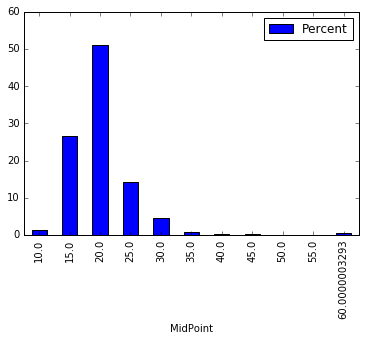

```python
# Set matplotlib to render graphics inline
%matplotlib inline

hist = tbl[['MPG_City']].histogram()

hist['BinDetails'].plot.bar(x='MidPoint', y='Percent')
```

## Exercise 7 - Grouping Data

### 7.1 Group-by

Now that we've done some basic statistics, let's look at how to group data. By grouping is handled by a parameter on the table: `groupby`. The brute force way of adding grouping to a table is to set it manually. The code below sets the `groupby` parameter to 'Origin'.

```python
tbl.set_param(groupby='Origin')
tbl
```

```
CASTable('cars', groupby='Origin')
```

We can then run the same `summary` action call as before and we will get the results grouped by Origin.

```python
output = tbl[['MSRP','MPG_CITY','MPG_Highway']].summary()
output
```

**§ ByGroupInfo**

ByGroupInfo

|  | Origin | Origin_f | _key_ |
| --- | --- | --- | --- |
| 0 | Asia | Asia | Asia |
| 1 | Europe | Europe | Europe |
| 2 | USA | USA | USA |

**§ ByGroup1.Summary**

Descriptive Statistics for CARS

| Origin | Column | Min | Max | N | NMiss | Mean | Sum | Std | StdErr | Var | USS | CSS | CV | TValue | ProbT |
| --- | --- | --- | --- | --- | --- | --- | --- | --- | --- | --- | --- | --- | --- | --- | --- |
| Asia | MSRP | 10280.0 | 89765.0 | 158.0 | 0.0 | 24741.322785 | 3909129.0 | 11321.069675 | 900.655944 | 1.281666e+08 | 1.168392e+11 | 2.012216e+10 | 45.757738 | 27.470338 | 7.525437e-62 |
| Asia | MPG_City | 13.0 | 60.0 | 158.0 | 0.0 | 22.012658 | 3478.0 | 6.733307 | 0.535673 | 4.533742e+01 | 8.367800e+04 | 7.117975e+03 | 30.588340 | 41.093453 | 6.417174e-86 |
| Asia | MPG_Highway | 17.0 | 66.0 | 158.0 | 0.0 | 28.265823 | 4466.0 | 6.770503 | 0.538632 | 4.583972e+01 | 1.334320e+05 | 7.196835e+03 | 23.952968 | 52.477026 | 1.853048e-101 |

**§ ByGroup2.Summary**

Descriptive Statistics for CARS

| Origin | Column | Min | Max | N | NMiss | Mean | Sum | Std | StdErr | Var | USS | CSS | CV | TValue | ProbT |
| --- | --- | --- | --- | --- | --- | --- | --- | --- | --- | --- | --- | --- | --- | --- | --- |
| Europe | MSRP | 16999.0 | 192465.0 | 123.0 | 0.0 | 48349.796748 | 5947025.0 | 25318.600464 | 2282.901323 | 6.410315e+08 | 3.657433e+11 | 7.820585e+10 | 52.365474 | 21.179101 | 1.104072e-42 |
| Europe | MPG_City | 12.0 | 38.0 | 123.0 | 0.0 | 18.731707 | 2304.0 | 3.289509 | 0.296605 | 1.082087e+01 | 4.447800e+04 | 1.320146e+03 | 17.561183 | 63.153699 | 4.846098e-95 |
| Europe | MPG_Highway | 14.0 | 46.0 | 123.0 | 0.0 | 26.008130 | 3199.0 | 4.167588 | 0.375779 | 1.736879e+01 | 8.531900e+04 | 2.118992e+03 | 16.024172 | 69.211292 | 9.190472e-100 |

**§ ByGroup3.Summary**

Descriptive Statistics for CARS

| Origin | Column | Min | Max | N | NMiss | Mean | Sum | Std | StdErr | Var | USS | CSS | CV | TValue | ProbT |
| --- | --- | --- | --- | --- | --- | --- | --- | --- | --- | --- | --- | --- | --- | --- | --- |
| USA | MSRP | 10995.0 | 81795.0 | 147.0 | 0.0 | 28377.442177 | 4171484.0 | 11711.982506 | 965.988036 | 1.371705e+08 | 1.384029e+11 | 2.002690e+10 | 41.272157 | 29.376598 | 3.686853e-63 |
| USA | MPG_City | 10.0 | 29.0 | 147.0 | 0.0 | 19.074830 | 2804.0 | 3.982992 | 0.328512 | 1.586423e+01 | 5.580200e+04 | 2.316177e+03 | 20.880878 | 58.064396 | 8.933082e-103 |
| USA | MPG_Highway | 12.0 | 37.0 | 147.0 | 0.0 | 26.013605 | 3824.0 | 5.396582 | 0.445103 | 2.912310e+01 | 1.037280e+05 | 4.251973e+03 | 20.745230 | 58.444064 | 3.586575e-103 |

elapsed 0.00266s · user 0.001s · sys 0.001s · mem 0.672MB

You'll notice that we get each By group in a separate result key. This is done to make the output as flexible as possible. When dealing with large sets of data, it is possible that you could end up with very large result sets coming back from CAS. The By groups are split so that it is possible to handle them piecemeal rather than as one big table. We will not go into detail on the way to construct action calls to handle results individually, but you can go to the SWAT documentation for more information.

In cases like this where the data is fairly small, you can concatenate all of the By group tables using the `concat_bygroups` method on the `CASResults` object. This gives you results similar to the non-By group code, but adds an index to the DataFrame that contains the By values.

```python
output.concat_bygroups()
```

**§ Summary**

Descriptive Statistics for CARS

| Origin | Column | Min | Max | N | NMiss | Mean | Sum | Std | StdErr | Var | USS | CSS | CV | TValue | ProbT |
| --- | --- | --- | --- | --- | --- | --- | --- | --- | --- | --- | --- | --- | --- | --- | --- |
| Asia | MSRP | 10280.0 | 89765.0 | 158.0 | 0.0 | 24741.322785 | 3909129.0 | 11321.069675 | 900.655944 | 1.281666e+08 | 1.168392e+11 | 2.012216e+10 | 45.757738 | 27.470338 | 7.525437e-62 |
| Asia | MPG_City | 13.0 | 60.0 | 158.0 | 0.0 | 22.012658 | 3478.0 | 6.733307 | 0.535673 | 4.533742e+01 | 8.367800e+04 | 7.117975e+03 | 30.588340 | 41.093453 | 6.417174e-86 |
| Asia | MPG_Highway | 17.0 | 66.0 | 158.0 | 0.0 | 28.265823 | 4466.0 | 6.770503 | 0.538632 | 4.583972e+01 | 1.334320e+05 | 7.196835e+03 | 23.952968 | 52.477026 | 1.853048e-101 |
| Europe | MSRP | 16999.0 | 192465.0 | 123.0 | 0.0 | 48349.796748 | 5947025.0 | 25318.600464 | 2282.901323 | 6.410315e+08 | 3.657433e+11 | 7.820585e+10 | 52.365474 | 21.179101 | 1.104072e-42 |
| Europe | MPG_City | 12.0 | 38.0 | 123.0 | 0.0 | 18.731707 | 2304.0 | 3.289509 | 0.296605 | 1.082087e+01 | 4.447800e+04 | 1.320146e+03 | 17.561183 | 63.153699 | 4.846098e-95 |
| Europe | MPG_Highway | 14.0 | 46.0 | 123.0 | 0.0 | 26.008130 | 3199.0 | 4.167588 | 0.375779 | 1.736879e+01 | 8.531900e+04 | 2.118992e+03 | 16.024172 | 69.211292 | 9.190472e-100 |
| USA | MSRP | 10995.0 | 81795.0 | 147.0 | 0.0 | 28377.442177 | 4171484.0 | 11711.982506 | 965.988036 | 1.371705e+08 | 1.384029e+11 | 2.002690e+10 | 41.272157 | 29.376598 | 3.686853e-63 |
| USA | MPG_City | 10.0 | 29.0 | 147.0 | 0.0 | 19.074830 | 2804.0 | 3.982992 | 0.328512 | 1.586423e+01 | 5.580200e+04 | 2.316177e+03 | 20.880878 | 58.064396 | 8.933082e-103 |
| USA | MPG_Highway | 12.0 | 37.0 | 147.0 | 0.0 | 26.013605 | 3824.0 | 5.396582 | 0.445103 | 2.912310e+01 | 1.037280e+05 | 4.251973e+03 | 20.745230 | 58.444064 | 3.586575e-103 |

Because SAS uses formatted values to do By grouping and Pandas typically works with raw values, there is a method called `reshape_bygroups` on the `SASDataFrame` object that allows you to change the representation of By groups in your DataFrames. You can indicate that you want By values (raw or formatted) as columns, an index, or neither. You can also specify a suffix to use when name collisions occur in column names if you have an action that can utilize the same column multiple times in the output.

### 7.2 Using Pandas-style Grouping

When we started this section, we mentioned that using the `set_param` method was the brute force way of setting By groupings. You can also use the Pandas-style way of setting groupings: the `groupby` method.

Using this returns a `CASTable`-like object with the `groupby` parameter set. All action calls on the new object behave just like a `CASTable` running the same action.

```python
tbl.del_param('groupby')
tbl
```

```
CASTable('cars')
```

```python
output = tbl[['MSRP','MPG_City']].groupby('Origin').summary()
output
```

**§ ByGroupInfo**

ByGroupInfo

|  | Origin | Origin_f | _key_ |
| --- | --- | --- | --- |
| 0 | Asia | Asia | Asia |
| 1 | Europe | Europe | Europe |
| 2 | USA | USA | USA |

**§ ByGroup1.Summary**

Descriptive Statistics for CARS

| Origin | Column | Min | Max | N | NMiss | Mean | Sum | Std | StdErr | Var | USS | CSS | CV | TValue | ProbT |
| --- | --- | --- | --- | --- | --- | --- | --- | --- | --- | --- | --- | --- | --- | --- | --- |
| Asia | MSRP | 10280.0 | 89765.0 | 158.0 | 0.0 | 24741.322785 | 3909129.0 | 11321.069675 | 900.655944 | 1.281666e+08 | 1.168392e+11 | 2.012216e+10 | 45.757738 | 27.470338 | 7.525437e-62 |
| Asia | MPG_City | 13.0 | 60.0 | 158.0 | 0.0 | 22.012658 | 3478.0 | 6.733307 | 0.535673 | 4.533742e+01 | 8.367800e+04 | 7.117975e+03 | 30.588340 | 41.093453 | 6.417174e-86 |

**§ ByGroup2.Summary**

Descriptive Statistics for CARS

| Origin | Column | Min | Max | N | NMiss | Mean | Sum | Std | StdErr | Var | USS | CSS | CV | TValue | ProbT |
| --- | --- | --- | --- | --- | --- | --- | --- | --- | --- | --- | --- | --- | --- | --- | --- |
| Europe | MSRP | 16999.0 | 192465.0 | 123.0 | 0.0 | 48349.796748 | 5947025.0 | 25318.600464 | 2282.901323 | 6.410315e+08 | 3.657433e+11 | 7.820585e+10 | 52.365474 | 21.179101 | 1.104072e-42 |
| Europe | MPG_City | 12.0 | 38.0 | 123.0 | 0.0 | 18.731707 | 2304.0 | 3.289509 | 0.296605 | 1.082087e+01 | 4.447800e+04 | 1.320146e+03 | 17.561183 | 63.153699 | 4.846098e-95 |

**§ ByGroup3.Summary**

Descriptive Statistics for CARS

| Origin | Column | Min | Max | N | NMiss | Mean | Sum | Std | StdErr | Var | USS | CSS | CV | TValue | ProbT |
| --- | --- | --- | --- | --- | --- | --- | --- | --- | --- | --- | --- | --- | --- | --- | --- |
| USA | MSRP | 10995.0 | 81795.0 | 147.0 | 0.0 | 28377.442177 | 4171484.0 | 11711.982506 | 965.988036 | 1.371705e+08 | 1.384029e+11 | 2.002690e+10 | 41.272157 | 29.376598 | 3.686853e-63 |
| USA | MPG_City | 10.0 | 29.0 | 147.0 | 0.0 | 19.074830 | 2804.0 | 3.982992 | 0.328512 | 1.586423e+01 | 5.580200e+04 | 2.316177e+03 | 20.880878 | 58.064396 | 8.933082e-103 |

elapsed 0.00226s · user 0.003s · mem 0.672MB

## Exercise 8 - SQL

SQL stands for Structured Query Language. According to ANSI (American National Standards Institute), it is the standard language for relational database management systems. In this section we illustrate how to use SQL to communicate with CAS server.

```python
conn.loadactionset('fedsql')
```

```
NOTE: Added action set 'fedsql'.
```

**§ actionset**

fedsql

elapsed 0.0212s · sys 0.003s · mem 0.0781MB

### 8.1 Execute an SQL query

`ExecDirect` is a CAS action in the FedSQL action set to execute SQL statements in the CAS environment.

```python
str1 = "select make, model, msrp, mpg_highway from cars where msrp > 80000 and mpg_highway > 20"
conn.fedsql.execDirect(query=str1)
```

**§ Result Set**

|  | Make | Model | MSRP | MPG_Highway |
| --- | --- | --- | --- | --- |
| 0 | Acura | NSX coupe 2dr manual S | 89765.0 | 24.0 |
| 1 | Audi | RS 6 4dr | 84600.0 | 22.0 |
| 2 | Jaguar | XKR coupe 2dr | 81995.0 | 23.0 |
| 3 | Jaguar | XKR convertible 2dr | 86995.0 | 23.0 |
| 4 | Mercedes-Benz | CL500 2dr | 94820.0 | 24.0 |
| 5 | Mercedes-Benz | S500 4dr | 86970.0 | 24.0 |
| 6 | Mercedes-Benz | SL500 convertible 2dr | 90520.0 | 23.0 |
| 7 | Mercedes-Benz | SL55 AMG 2dr | 121770.0 | 21.0 |
| 8 | Porsche | 911 Carrera 4S coupe 2dr (convert) | 84165.0 | 24.0 |
| 9 | Porsche | 911 GT2 2dr | 192465.0 | 24.0 |

elapsed 0.126s · user 0.016s · sys 0.013s · mem 3.64MB

### 8.2 Group-by and summary statistics

```python
str1 = "select origin, mean(mpg_highway), std(mpg_highway) from cars group by origin"
conn.fedsql.execDirect(query=str1)
```

**§ Result Set**

|  | Origin | MEAN | STD |
| --- | --- | --- | --- |
| 0 | Asia | 28.265823 | 6.770503 |
| 1 | Europe | 26.008130 | 4.167588 |
| 2 | USA | 26.013605 | 5.396582 |

elapsed 0.0203s · user 0.021s · sys 0.005s · mem 10.2MB

Show the SQL logic

```python
str1 = "select origin, mean(mpg_highway), std(mpg_highway) from cars group by origin"
conn.fedsql.execDirect(query=str1, method=True)
```

```
Methods for full query plan
----------------------------
        Agg
          Sort
            SeqScan from CASUSER(viyauser).CARS

Methods for stage 1
--------------------
        Agg
            SeqScan with _pushed_ order by from CASUSER(viyauser).CARS

        Stage query: select "T1"."Origin", AVG ("T1"."MPG_Highway")  as "MEAN", STDDEV ("T1"."MPG_Highway")  as "STD" from "CASUSER(viyauser)"."CARS" {options tableID=1} T1 group by "T1"."Origin"

        Number of SQL I/O threads: 4
```

**§ Result Set**

|  | Origin | MEAN | STD |
| --- | --- | --- | --- |
| 0 | Asia | 28.265823 | 6.770503 |
| 1 | Europe | 26.008130 | 4.167588 |
| 2 | USA | 26.013605 | 5.396582 |

elapsed 0.0155s · user 0.018s · sys 0.005s · mem 9.92MB

### 8.3 Create a new CAS table using SQL

```python
str1 = """
    create table aggregated1 as
        select origin, mean(mpg_highway), std(mpg_highway)
        from cars group by origin
"""

conn.fedsql.execDirect(query=str1)
```

```
NOTE: Table AGGREGATED1 was created in caslib CASUSER(viyauser) with 3 rows returned.
```

elapsed 0.0137s · user 0.022s · sys 0.005s · mem 10MB

```python
conn.tableinfo()
```

**§ TableInfo**

|  | Name | Rows | Columns | Encoding | CreateTimeFormatted | ModTimeFormatted | JavaCharSet | CreateTime | ModTime | Global | Repeated | View | SourceName | SourceCaslib | Compressed | Creator | Modifier |
| --- | --- | --- | --- | --- | --- | --- | --- | --- | --- | --- | --- | --- | --- | --- | --- | --- | --- |
| 0 | _T_8B910465_7F1F62C95F88 | 428 | 15 | utf-8 | 09Sep2016:13:45:32 | 09Sep2016:13:45:32 | UTF8 | 1.789048e+09 | 1.789048e+09 | 0 | 0 | 0 | _T_8B910465_7F1F62C95F88 |  | 0 | viyauser |  |
| 1 | CARS | 428 | 15 | utf-8 | 09Sep2016:13:45:32 | 09Sep2016:13:45:32 | UTF8 | 1.789048e+09 | 1.789048e+09 | 0 | 0 | 0 |  |  | 0 | viyauser |  |
| 2 | DATA.CARS | 428 | 15 | utf-8 | 09Sep2016:13:45:34 | 09Sep2016:13:45:34 | UTF8 | 1.789048e+09 | 1.789048e+09 | 0 | 0 | 0 | Data/cars.csv | CASUSER(viyauser) | 0 | viyauser |  |
| 3 | AGGREGATED1 | 3 | 3 | utf-8 | 09Sep2016:13:45:43 | 09Sep2016:13:45:43 | UTF8 | 1.789048e+09 | 1.789048e+09 | 0 | 0 | 0 |  |  | 0 | viyauser |  |

elapsed 0.000587s · user 0.001s · mem 0.0718MB

You can delete a table usig the dropTable action.

```python
# conn.dropTable('aggregated1')
```

Continue to work on the table created by SQL

```python
tbl_temp = conn.CASTable('aggregated1')
```

```python
tbl_temp.fetch()
```

**§ Fetch**

Selected Rows from Table AGGREGATED1

|  | Origin | MEAN | STD |
| --- | --- | --- | --- |
| 0 | Asia | 28.265823 | 6.770503 |
| 1 | Europe | 26.008130 | 4.167588 |
| 2 | USA | 26.013605 | 5.396582 |

elapsed 0.00117s · user 0.001s · mem 0.556MB

### 8.4 Table Join

```python
str1 = """
    create table aggregated2 as
        select origin, type, mean(mpg_highway), std(mpg_highway)
        from cars
        group by origin, type
"""

conn.fedsql.execDirect(query=str1)
```

```
NOTE: Table AGGREGATED2 was created in caslib CASUSER(viyauser) with 15 rows returned.
```

elapsed 0.0169s · user 0.03s · sys 0.002s · mem 10.5MB

```python
str1 = """
    select a.origin, a.type, b.mean as Average_Origin, a.mean as Average_Type
    from aggregated2 as a
        left join aggregated1 as b
    on b.origin = a.origin
"""

conn.fedsql.execDirect(query=str1)
```

**§ Result Set**

|  | Origin | Type | AVERAGE_ORIGIN | AVERAGE_TYPE |
| --- | --- | --- | --- | --- |
| 0 | Asia | Hybrid | 28.265823 | 56.000000 |
| 1 | Asia | Truck | 28.265823 | 22.000000 |
| 2 | Europe | Sports | 26.008130 | 25.130435 |
| 3 | USA | Sports | 26.013605 | 24.222222 |
| 4 | Asia | SUV | 28.265823 | 21.680000 |
| 5 | Asia | Wagon | 28.265823 | 28.181818 |
| 6 | Europe | Wagon | 26.008130 | 26.583333 |
| 7 | USA | Truck | 26.013605 | 20.500000 |
| 8 | Asia | Sedan | 28.265823 | 29.968085 |
| 9 | Europe | SUV | 26.008130 | 18.700000 |
| 10 | USA | SUV | 26.013605 | 20.040000 |
| 11 | USA | Wagon | 26.013605 | 29.714286 |
| 12 | Asia | Sports | 28.265823 | 26.647059 |
| 13 | Europe | Sedan | 26.008130 | 27.115385 |
| 14 | USA | Sedan | 26.013605 | 28.544444 |

elapsed 0.021s · user 0.017s · sys 0.018s · mem 10.2MB

## Exercise 9 - DATA Step

You can submit SAS data step codes using the `runCode` action! Don't forget the new data set option REPLACE=YES if you want to replace an existing data set in the same CAS server. By default the new table CARS_TEMP is saved to the CASUSER library in the CAS server.

```python
conn.runCode(code="""
    data cars_temp(replace=yes);
        set cars;
        sqrt_MSRP = sqrt(MSRP);
        MPG_avg = (MPG_city+MPG_highway)/2;
    run;
""")
```

**§ InputCasTables**

|  | casLib | Name | Rows | Columns | casTable |
| --- | --- | --- | --- | --- | --- |
| 0 | CASUSER(viyauser) | cars | 428 | 15 | CASTable('cars', caslib='CASUSER(viyauser)') |

**§ OutputCasTables**

|  | casLib | Name | Rows | Columns | casTable |
| --- | --- | --- | --- | --- | --- |
| 0 | CASUSER(viyauser) | cars_temp | 428 | 17 | CASTable('cars_temp', caslib='CASUSER(viyauser)') |

elapsed 0.0466s · user 0.01s · sys 0.005s · mem 8.22MB

```python
conn.tableinfo()
```

**§ TableInfo**

|  | Name | Rows | Columns | Encoding | CreateTimeFormatted | ModTimeFormatted | JavaCharSet | CreateTime | ModTime | Global | Repeated | View | SourceName | SourceCaslib | Compressed | Creator | Modifier |
| --- | --- | --- | --- | --- | --- | --- | --- | --- | --- | --- | --- | --- | --- | --- | --- | --- | --- |
| 0 | _T_8B910465_7F1F62C95F88 | 428 | 15 | utf-8 | 09Sep2016:13:45:32 | 09Sep2016:13:45:32 | UTF8 | 1.789048e+09 | 1.789048e+09 | 0 | 0 | 0 | _T_8B910465_7F1F62C95F88 |  | 0 | viyauser |  |
| 1 | CARS | 428 | 15 | utf-8 | 09Sep2016:13:45:32 | 09Sep2016:13:45:32 | UTF8 | 1.789048e+09 | 1.789048e+09 | 0 | 0 | 0 |  |  | 0 | viyauser |  |
| 2 | DATA.CARS | 428 | 15 | utf-8 | 09Sep2016:13:45:34 | 09Sep2016:13:45:34 | UTF8 | 1.789048e+09 | 1.789048e+09 | 0 | 0 | 0 | Data/cars.csv | CASUSER(viyauser) | 0 | viyauser |  |
| 3 | AGGREGATED1 | 3 | 3 | utf-8 | 09Sep2016:13:45:43 | 09Sep2016:13:45:43 | UTF8 | 1.789048e+09 | 1.789048e+09 | 0 | 0 | 0 |  |  | 0 | viyauser |  |
| 4 | AGGREGATED2 | 15 | 4 | utf-8 | 09Sep2016:13:45:43 | 09Sep2016:13:45:43 | UTF8 | 1.789048e+09 | 1.789048e+09 | 0 | 0 | 0 |  |  | 0 | viyauser |  |
| 5 | CARS_TEMP | 428 | 17 | utf-8 | 09Sep2016:13:45:43 | 09Sep2016:13:45:43 | UTF8 | 1.789048e+09 | 1.789048e+09 | 0 | 0 | 0 |  |  | 0 | viyauser |  |

elapsed 0.000788s · sys 0.001s · mem 0.0752MB

```python
tbl_cars_temp = conn.CASTable('cars_temp')
tbl_cars_temp[['sqrt_MSRP','MPG_avg']].summary()
```

**§ Summary**

Descriptive Statistics for CARS_TEMP

|  | Column | Min | Max | N | NMiss | Mean | Sum | Std | StdErr | Var | USS | CSS | CV | TValue | ProbT |
| --- | --- | --- | --- | --- | --- | --- | --- | --- | --- | --- | --- | --- | --- | --- | --- |
| 0 | sqrt_MSRP | 101.390335 | 438.708331 | 428.0 | 0.0 | 175.121390 | 74951.954867 | 45.959648 | 2.221543 | 2112.289203 | 14027638.00 | 901947.489887 | 26.244451 | 78.828705 | 1.415239e-256 |
| 1 | MPG_avg | 11.000000 | 63.000000 | 428.0 | 0.0 | 23.452103 | 10037.500000 | 5.408331 | 0.261422 | 29.250042 | 247890.25 | 12489.768107 | 23.061177 | 89.709911 | 3.448353e-279 |

elapsed 0.00557s · sys 0.003s · mem 0.662MB

## Exercise 10 - Building Analytical Models

You need to load an modeling action before you use it. Let's load the action sets for regression and decision tree models

```python
conn.loadactionset('regression')
conn.loadactionset('decisiontree')

tbl = conn.CASTable('cars')
```

```
NOTE: Added action set 'regression'.
NOTE: Added action set 'decisiontree'.
```

The regression action set contains three models: linear regressions, logistic regressions, and generalized linear models.

```python
conn.help(actionset='regression')
```

```
NOTE: Information for action set 'regression':
NOTE:    regression
NOTE:       glm - Fits linear regression models using the method of least squares
NOTE:       genmod - Fits generalized linear regression models
NOTE:       logistic - Fits logistic regression models
```

**§ regression**

|  | name | description |
| --- | --- | --- |
| 0 | glm | Fits linear regression models using the method... |
| 1 | genmod | Fits generalized linear regression models |
| 2 | logistic | Fits logistic regression models |

elapsed 0.00434s · user 0.001s · mem 0.0451MB

Let us build a linear regression model to predict the MSRP values of the automobiles using the CARS data set.

```python
output1 = tbl.glm(
    target = 'MSRP',
    nominals = ['Type', 'Origin'],
    inputs = ['Type', 'Origin', 'MPG_City', 'Length', 'Weight']
)
```

```python
output1
```

**§ ModelInfo**

Model Information

|  | RowId | Description | Value |
| --- | --- | --- | --- |
| 0 | DATA | Data Source | CARS |
| 1 | RESPONSEVAR | Response Variable | MSRP |

**§ NObs**

Number of Observations

|  | RowId | Description | Value |
| --- | --- | --- | --- |
| 0 | NREAD | Number of Observations Read | 428.0 |
| 1 | NUSED | Number of Observations Used | 428.0 |

**§ ClassInfo**

Class Level Information

|  | Class | Levels | Values |
| --- | --- | --- | --- |
| 0 | Type | 6.0 | Hybrid SUV Sedan Sports Truck Wagon |
| 1 | Origin | 3.0 | Asia Europe USA |

**§ Dimensions**

Dimensions

|  | RowId | Description | Value |
| --- | --- | --- | --- |
| 0 | NEFFECTS | Number of Effects | 6 |
| 1 | NPARMS | Number of Parameters | 13 |

**§ ANOVA**

Analysis of Variance

|  | RowId | Source | DF | SS | MS | FValue | ProbF |
| --- | --- | --- | --- | --- | --- | --- | --- |
| 0 | MODEL | Model | 10.0 | 9.788809e+10 | 9.788809e+09 | 64.441212 | 2.863778e-78 |
| 1 | ERROR | Error | 417.0 | 6.334352e+10 | 1.519029e+08 | NaN | NaN |
| 2 | TOTAL | Corrected Total | 427.0 | 1.612316e+11 | NaN | NaN | NaN |

**§ FitStatistics**

Fit Statistics

|  | RowId | Description | Value |
| --- | --- | --- | --- |
| 0 | RMSE | Root MSE | 1.232489e+04 |
| 1 | RSQUARE | R-Square | 6.071272e-01 |
| 2 | ADJRSQ | Adj R-Sq | 5.977057e-01 |
| 3 | AIC | AIC | 8.503842e+03 |
| 4 | AICC | AICC | 8.504594e+03 |
| 5 | SBC | SBC | 8.118493e+03 |
| 6 | TRAIN_ASE | ASE | 1.479989e+08 |

**§ ParameterEstimates**

Parameter Estimates

|  | Effect | Type | Origin | Parameter | DF | Estimate | StdErr | tValue | Probt |
| --- | --- | --- | --- | --- | --- | --- | --- | --- | --- |
| 0 | Intercept |  |  | Intercept | 1 | -24437.969421 | 16457.304807 | -1.484931 | 1.383175e-01 |
| 1 | Type | Hybrid |  | Type Hybrid | 1 | 32712.213902 | 10759.213364 | 3.040391 | 2.511673e-03 |
| 2 | Type | SUV |  | Type SUV | 1 | -3143.063706 | 3130.508120 | -1.004011 | 3.159557e-01 |
| 3 | Type | Sedan |  | Type Sedan | 1 | 2292.189910 | 2406.138849 | 0.952642 | 3.413231e-01 |
| 4 | Type | Sports |  | Type Sports | 1 | 24150.756192 | 3062.016347 | 7.887207 | 2.737502e-14 |
| 5 | Type | Truck |  | Type Truck | 1 | -11340.453498 | 3609.223220 | -3.142076 | 1.797217e-03 |
| 6 | Type | Wagon |  | Type Wagon | 0 | 0.000000 | NaN | NaN | NaN |
| 7 | Origin |  | Asia | Origin Asia | 1 | 1903.248827 | 1503.771197 | 1.265651 | 2.063449e-01 |
| 8 | Origin |  | Europe | Origin Europe | 1 | 17995.412825 | 1787.406597 | 10.067890 | 1.734237e-21 |
| 9 | Origin |  | USA | Origin USA | 0 | 0.000000 | NaN | NaN | NaN |
| 10 | MPG_City |  |  | MPG_City | 1 | -742.336207 | 265.209506 | -2.799056 | 5.363126e-03 |
| 11 | Length |  |  | Length | 1 | 175.595793 | 82.233208 | 2.135339 | 3.331544e-02 |
| 12 | Weight |  |  | Weight | 1 | 8.436445 | 1.921768 | 4.389939 | 1.438777e-05 |

**§ Timing**

Task Timing

|  | RowId | Task | Time | RelTime |
| --- | --- | --- | --- | --- |
| 0 | SETUP | Setup and Parsing | 0.021932 | 0.459167 |
| 1 | LEVELIZATION | Levelization | 0.003773 | 0.078990 |
| 2 | INITIALIZATION | Model Initialization | 0.002705 | 0.056633 |
| 3 | SSCP | SSCP Computation | 0.013514 | 0.282928 |
| 4 | FITTING | Model Fitting | 0.004904 | 0.102670 |
| 5 | CLEANUP | Cleanup | 0.000867 | 0.018149 |
| 6 | TOTAL | Total | 0.047765 | 1.000000 |

elapsed 0.0493s · user 0.006s · sys 0.009s · mem 0.794MB

You can get the results in a ODS-like style too.

```python
from swat.render import render_html
render_html(output1)
```

| Model Information |  |  |
| --- | --- | --- |
| DATA | Data Source | CARS |
| RESPONSEVAR | Response Variable | MSRP |

| Number of Observations |  |  |
| --- | --- | --- |
| NREAD | Number of Observations Read | 428 |
| NUSED | Number of Observations Used | 428 |

| Class Level Information |  |  |
| --- | --- | --- |
| Type | 6 | Hybrid SUV Sedan Sports Truck Wagon |
| Origin | 3 | Asia Europe USA |

| Dimensions |  |  |
| --- | --- | --- |
| NEFFECTS | Number of Effects | 6 |
| NPARMS | Number of Parameters | 13 |

| Analysis of Variance |  |  |  |  |  |  |
| --- | --- | --- | --- | --- | --- | --- |
| MODEL | Model | 10 | 97888093989 | 9788809398.9 | 64.441212227 | 2.863778E-78 |
| ERROR | Error | 417 | 63343524714 | 151902936.96 | nan | nan |
| TOTAL | Corrected Total | 427 | 161231618703 | nan | nan | nan |

| Fit Statistics |  |  |
| --- | --- | --- |
| RMSE | Root MSE | 12324.890951 |
| RSQUARE | R-Square | 0.6071271552 |
| ADJRSQ | Adj R-Sq | 0.597705744 |
| AIC | AIC | 8503.8421606 |
| AICC | AICC | 8504.5939678 |
| SBC | SBC | 8118.4925157 |
| TRAIN_ASE | ASE | 147998889.52 |

| Parameter Estimates |  |  |  |  |  |  |  |  |
| --- | --- | --- | --- | --- | --- | --- | --- | --- |
| Intercept |  |  | Intercept | 1 | -24437.96942 | 16457.304807 | -1.484931446 | 0.1383175144 |
| Type | Hybrid |  | Type Hybrid | 1 | 32712.213902 | 10759.213364 | 3.0403908535 | 0.0025116732 |
| Type | SUV |  | Type SUV | 1 | -3143.063706 | 3130.5081203 | -1.004010718 | 0.3159556852 |
| Type | Sedan |  | Type Sedan | 1 | 2292.1899097 | 2406.1388494 | 0.9526424089 | 0.3413231382 |
| Type | Sports |  | Type Sports | 1 | 24150.756192 | 3062.0163467 | 7.8872068134 | 2.737502E-14 |
| Type | Truck |  | Type Truck | 1 | -11340.4535 | 3609.2232203 | -3.142075955 | 0.001797217 |
| Type | Wagon |  | Type Wagon | 0 | 0 | nan | nan | nan |
| Origin |  | Asia | Origin Asia | 1 | 1903.248827 | 1503.771197 | 1.2656505397 | 0.2063449053 |
| Origin |  | Europe | Origin Europe | 1 | 17995.412825 | 1787.4065967 | 10.067889902 | 1.734237E-21 |
| Origin |  | USA | Origin USA | 0 | 0 | nan | nan | nan |
| MPG_City |  |  | MPG_City | 1 | -742.3362069 | 265.20950581 | -2.799055805 | 0.0053631256 |
| Length |  |  | Length | 1 | 175.59579301 | 82.233207647 | 2.1353392143 | 0.0333154353 |
| Weight |  |  | Weight | 1 | 8.4364452275 | 1.9217683405 | 4.3899387088 | 0.0000143878 |

| Task Timing |  |  |  |
| --- | --- | --- | --- |
| SETUP | Setup and Parsing | 0.0219321251 | 0.4591671201 |
| LEVELIZATION | Levelization | 0.003772974 | 0.0789903215 |
| INITIALIZATION | Model Initialization | 0.0027050972 | 0.05663344 |
| SSCP | SSCP Computation | 0.0135140419 | 0.2829276084 |
| FITTING | Model Fitting | 0.0049040318 | 0.1026699477 |
| CLEANUP | Cleanup | 0.00086689 | 0.0181490559 |
| TOTAL | Total | 0.0477650166 | 1 |

Next let us build a decision tree model to predict MSRP.

```python
output1 = tbl.dtreetrain(
    target = 'MSRP',
    nominals = ['Type', 'Origin'],
    inputs = ['Type', 'Origin', 'MPG_City', 'Length', 'Weight'],
    casout = conn.CASTable("treeModel"),
    varImp = True
)
```

```python
output1
```

**§ ModelInfo**

Decision Tree for CARS

|  | Descr | Value |
| --- | --- | --- |
| 0 | Number of Tree Nodes | 4.700000e+01 |
| 1 | Max Number of Branches | 2.000000e+00 |
| 2 | Number of Levels | 6.000000e+00 |
| 3 | Number of Leaves | 2.400000e+01 |
| 4 | Number of Bins | 2.000000e+01 |
| 5 | Minimum Size of Leaves | 5.000000e+00 |
| 6 | Maximum Size of Leaves | 1.030000e+02 |
| 7 | Number of Variables | 5.000000e+00 |
| 8 | Alpha for Cost-Complexity Pruning | 0.000000e+00 |
| 9 | Number of Observations Used | 4.280000e+02 |
| 10 | Maximum STD of Leaves | 4.922019e+04 |
| 11 | Minimum STD of Leaves | 9.862942e+02 |
| 12 | Mean Squared Error | 9.431782e+07 |

**§ DTreeVarImpInfo**

Decision Tree for CARS

|  | Variable | Importance | Std | Count |
| --- | --- | --- | --- | --- |
| 0 | MPG_City | 4.796464e+10 | 8.995686e+09 | 6.0 |
| 1 | Origin | 4.186990e+10 | 0.000000e+00 | 1.0 |
| 2 | Type | 1.592548e+10 | 2.559214e+09 | 8.0 |
| 3 | Length | 1.181178e+10 | 2.312614e+09 | 4.0 |
| 4 | Weight | 3.291795e+09 | 7.979902e+08 | 4.0 |

**§ OutputCasTables**

|  | casLib | Name | Rows | Columns | casTable |
| --- | --- | --- | --- | --- | --- |
| 0 | CASUSER(viyauser) | treeModel | 47 | 31 | CASTable('treeModel', caslib='CASUSER(viyauser)') |

elapsed 0.0218s · user 0.005s · sys 0.007s · mem 2.19MB

```python
conn.CASTable("treeModel1").fetch()
```

[output not shown]

elapsed 6e-05s · user 0.486s · sys 0.276s

Last but not least, let us visualize the importance of the predictors using Cufflinks.

```python
output1['DTreeVarImpInfo'].sort_values(by='Importance').iplot(kind='barh',x='Variable',y='Importance')
```

[interactive chart not shown]